# 如何烘焙 π · How to Bake Pi — Eugenia Cheng

[figure not shown]

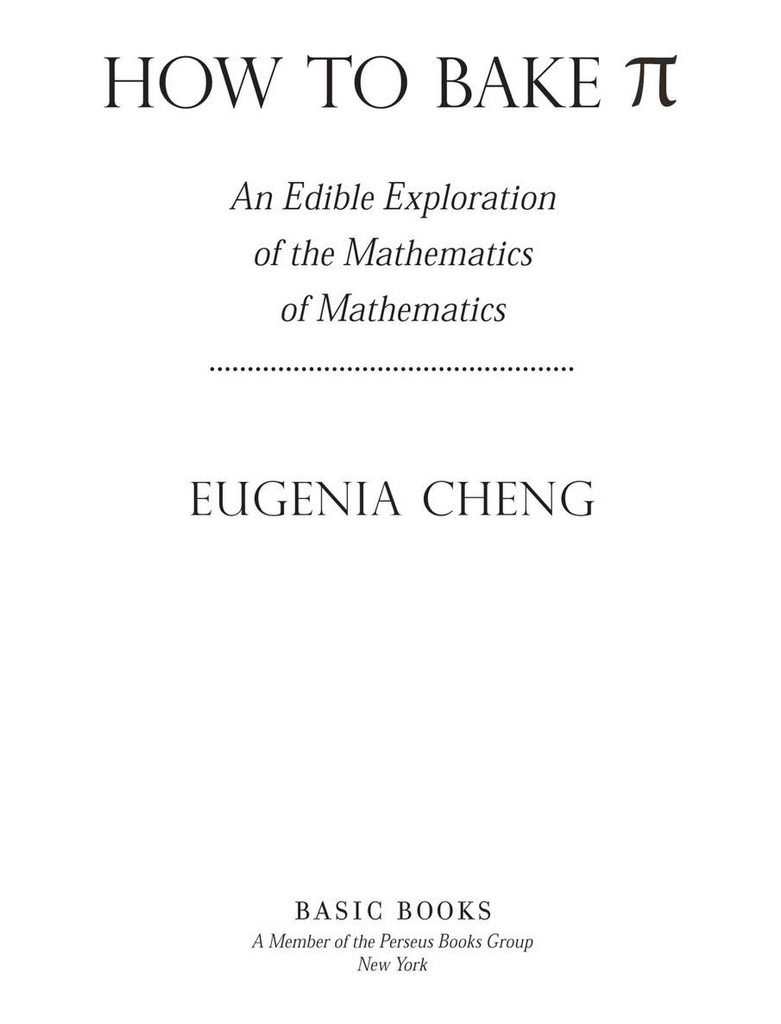

版权 © 2015，郑乐隽（Eugenia Cheng）

Copyright © 2015 by Eugenia Cheng

由 Basic Books 出版，

Published by Basic Books,

该出版社为珀尔修斯出版集团成员。

A Member of the Perseus Books Group

版权所有。在美国印刷。除评论文章或书评中的简短引文外，未经书面许可，不得以任何形式复制本书的任何部分。如需了解详情，请联系 Basic Books，地址：250 West 57th Street, New York, NY 10107。

All rights reserved. Printed in the United States of America. No part of this book may be reproduced in any manner whatsoever without written permission except in the case of brief quotations embodied in critical articles and reviews. For information, address Basic Books, 250 West 57th Street, New York, NY 10107.

美国的企业、机构及其他组织批量购买 Basic Books 出版的图书，可享受特别折扣。详情请联系珀尔修斯出版集团特别市场部，地址：2300 Chestnut Street, Suite 200, Philadelphia, PA 19103；电话：(800) 810–4145，分机 5000；电子邮箱：special.markets@perseusbooks.com。

Books published by Basic Books are available at special discounts for bulk purchases in the United States by corporations, institutions, and other organizations. For more information, please contact the Special Markets Department at the Perseus Books Group, 2300 Chestnut Street, Suite 200, Philadelphia, PA 19103, or call (800) 810–4145, ext. 5000, or e-mail special.markets@perseusbooks.com.

美国国会图书馆备有本书的编目记录。

A catalog record for this book is available from the Library of Congress.

美国国会图书馆控制号：2014957937

Library of Congress Control Number: 2014957937

ISBN：978-0-465-05169-4（电子书）

ISBN: 978-0-465-05169-4 (e-book)

10 9 8 7 6 5 4 3 2 1

献给我的父母和马丁·海兰德

*To my parents and Martin Hyland*

纪念克里斯汀·彭布里奇

*In memory of Christine Pembridge*

# 目录Contents

前言

第一部分：数学

**PART I: MATH**

1 什么是数学？

1 What Is Math?

2 抽象

2 Abstraction

3 原理

3 Principles

4 过程

4 Process

5 推广

5 Generalization

6 内在与外在

6 Internal vs. External

7 公理化

7 Axiomatization

8 数学是什么

8 What Mathematics Is

第二部分：范畴论

**PART II: CATEGORY THEORY**

9 什么是范畴论？

9 What Is Category Theory?

10 情境

10 Context

11 关系

11 Relationships

12 结构

12 Structure

13 相同

13 Sameness

14 泛性质

14 Universal Properties

15 范畴论是什么

15 What Category Theory Is

致谢

Acknowledgments

索引

Index

有人说，数学是一座美妙的花园。如果没有您的引导，我知道自己一定会在其中迷路。谢谢您带领我们走过那条最美丽的入园小径。

They say mathematics is a glorious garden. I know I would certainly lose my way in it without your guidance. Thank you for walking us through the most beautiful entrance pathway.

摘自一位学生写给作者的信

*From a student’s letter to the author*

芝加哥大学，2014 年 6 月

*University of Chicago, June 2014*

# 前言Prologue

下面是凝脂奶油的做法。

Here is a recipe for clotted cream.

#### 配料Ingredients

奶油

Cream

#### 做法Method

1. 将奶油倒入电饭煲。

1. Pour the cream into a rice cooker.

2. 调至“保温”档，锅盖稍稍打开，静置约 8 小时。

2. Leave it on the “keep warm” setting with the lid slightly open, for about 8 hours.

3. 放入冰箱冷藏约 8 小时。

3. Cool it in the fridge for about 8 hours.

4. 用勺子舀出最上面的一层，这就是凝脂奶油。

4. Scoop the top part off: that’s the clotted cream.

那么，这和数学到底有什么关系呢？

What on earth does this have to do with math?

### 关于数学的迷思Math Myths

数学是关于数字的科学。

Myth: *“Math is all about numbers.”*

你也许认为电饭煲就是用来煮米饭的。这话没错，但同一个电器也可以用来做其他的事情：做凝脂奶油，煮蔬菜，蒸一只鸡。同样，数学的确关乎数字，但它也关乎很多其他的东西。

You might think that rice cookers are for cooking rice. This is true, but the same piece of equipment can be used for other things as well: making clotted cream, cooking vegetables, steaming a chicken. Likewise, math is about numbers, but it’s about many other things as well.

数学是关于得出正确答案的科学。

Myth: *“Math is all about getting the right answer.”*

烹饪是关于把各种配料调和在一起，做出美味食物的艺术。有时它更强调的是方法，而不是配料本身，就像做凝脂奶油的食谱一样，配料只有一样，整个食谱讲的是一种方法。数学是关于如何把各种想法组合到一起，创造出令人激动的新想法的科学。同样，有时它更强调的是方法，而不是“配料”本身。

Cooking is about ways of putting ingredients together to make delicious food. Sometimes it’s more about the method than the ingredients, just as in the recipe for clotted cream, which only has one ingredient—the entire recipe is just a method. Math is about ways of putting ideas together to make exciting new ideas. And sometimes it’s more about the method than the “ingredients.”

数学是非对即错的科学。

Myth: *“Math is all either right or wrong.”*

烹饪可能会失败——你的蛋奶糊可能会结块，你的蛋奶酥可能会塌掉，你的鸡肉可能没熟，让每个吃了它的人都食物中毒了。或者，某些食物可能并不会使你中毒，但总有一些食物要比另一些更好吃。有时候，烹饪“失败”了，你却在无意中发明了一种美妙的新食谱：塌掉的巧克力蛋奶酥柔软而绵密；做饼干时忘了把巧克力融掉，结果做出了巧克力豆饼干。数学也是如此。在学校，如果你写下10+4=2，你会被告知这是错的，但在某些情况下，这个等式是对的，比如计算时间——上午10点过去4个小时就是下午2点。事实上，数学的世界比你所知道的更加神奇和不可思议……

Cooking can go wrong—your eggs can curdle, your soufflé can collapse, your chicken can be undercooked and give everyone food poisoning. But even if it doesn’t poison you, some food tastes better than other food. And sometimes when cooking goes “wrong” you have actually accidentally invented a delicious new recipe. Fallen chocolate soufflé is deliciously dark and gooey. If you forget to melt the chocolate for your cookies, you get chocolate chip cookies. Math is like this too. In high school if you write 10 + 4 = 2 you will be told that is wrong, but actually that’s correct in some circumstances, such as telling the time—four hours later than 10:00 is indeed 2:00. The world of math is more weird and wonderful than some people want to tell you.

你是数学家？那你一定非常聪明。

Myth: *“You’re a mathematician? You must be really clever.”*

虽然我很喜欢别人说我聪明，但这个迷思更说明了人们普遍认为数学很难。一个许多人不理解的事实是，数学的目的是让事情简单化。这里有个问题——如果数学是为了简化，就说明这件事情一开始是复杂的。数学的确很难，但它也能让复杂的事情变得简单。事实上，正因为数学很难，数学才能让数学变得更容易。

Much as I like the idea that I am very clever, this popular myth shows that people think math is hard. The little-understood truth is that the aim of math is to make things easier. Herein lies the problem—if you need to make things easier, it gives the impression that they were hard in the first place. Math *is* hard, but it makes hard things easier. In fact, since math is a hard thing, math also makes math easier.

很多人要么害怕数学，要么很容易被数学搞糊涂，当然也可能两者兼具。或者，也有可能是他们在学校里上过的数学课让他们对这一切很反感。我能理解这些，我也曾经对学校里的体育课很反感，并且从未真正克服这一障碍。我在运动方面的表现实在很差，我当时的老师简直难以相信世界上竟然真的存在运动能力这么差的人。但现在我也挺健康的，甚至还参加了纽约马拉松的比赛。至少现在，我体会到了体育锻炼的好处，但我仍然害怕任何一种团队性的体育项目。

Many people are afraid of math, or baffled by it, or both. Or they were completely turned off it by their classes in high school. I understand this—I was completely turned off sports in high school and have never really recovered. I was so bad at sports in high school, my teachers were incredulous that anybody so bad at sports could exist. And yet I’m quite fit now and have even run the New York City Marathon. At least I now appreciate physical exercise, but I still have a horror of any kind of team sports.

你究竟是怎么做数学研究的呢？你也不可能再发现一个新的数字了啊！

Myth: *“How can you do research in math? You can’t just discover a new number.”*

这本书就是我对这个问题的回答。如果我正身处一场鸡尾酒会，而有其他人向我提出了这个问题，那我只能说我很难给出一个言简意赅又不失新意的答案，这个答案要么因为太长而占用听者太多的时间，要么因为太出乎意料而吓到旁边的人。是的，在一场正式的宴会上，吓到别人的方法之一就是谈论数学。

This book is my answer to that question. It’s hard to answer it quickly at a cocktail party without sounding trite, or taking up too much of someone’s time, or shocking the gathered company. Yes, one way to shock people at a polite party is to talk about math.

没错，你不能凭空发现一个新的数。那么，我们究竟能在数学里发现什么新东西？要解释这种“新数学”可能研究什么，我得先澄清一些关于数学本身的误解。事实上，数学不仅仅研究数；我要介绍的这个分支甚至根本不研究数。它叫作

It’s true, you can’t just discover a new number. So what can we discover that’s new in math? In order to explain what this “new math” could possibly be about, I need to clear up some misunderstandings about what math is in the first place. Indeed, not only is math not just about numbers, but the branch of math I’m going to describe is actually not about numbers at all. It’s called

范畴论

CATEGORY THEORY

也可以理解为“数学的数学”。它研究关系、情境、过程、原理、结构、蛋糕和蛋奶糊。

and it can be thought of as the “mathematics of mathematics.” It’s about relationships, contexts, processes, principles, structures, cakes, custard.

是的，甚至是关于蛋奶糊的。因为数学是关于类比的，而接下来我将用各式各样的类比来解释数学是如何运作的，包括蛋奶糊、蛋糕、派、松饼、甜甜圈、贝果面包、蛋黄酱、酸奶、千层面和寿司。

Yes, even custard. Because mathematics is about drawing analogies, and I’m going to be drawing analogies with all sorts of things to explain how math works, including custard, cake, pie, pastry, donuts, bagels, mayonnaise, yogurt, lasagne, sushi.

不管你认为数学是什么，现在，请暂时放下你的想法。  
我将给你一个与众不同的答案。

*Whatever you think math is . . . let go of it now. This is going to be different.*

# 第一部分：数学Part I Math

## 1 什么是数学？Chapter 1 What Is Math?

### 无麸质巧克力布朗尼Gluten-Free Chocolate Brownies

#### 配料Ingredients

4 盎司黄油

4 oz. butter

5 盎司黑巧克力

5 oz. dark chocolate

2 个中等大小的鸡蛋

2 medium eggs

6 盎司糖

6 oz. sugar

3 盎司土豆粉

3 oz. potato flour

#### 做法Method

1. 将黄油与巧克力融化，搅拌均匀，稍稍冷却。

1. Melt the butter and chocolate, stir together, and allow to cool a little.

2. 将鸡蛋与糖搅打至蓬松。

2. Whisk the eggs and the sugar together until fluffy.

3. 缓缓把巧克力打入蛋液中。

3. Beat the chocolate into the egg mixture slowly.

4. 轻轻拌入土豆粉。

4. Fold in the potato flour.

5. 分装在很小的独立纸杯蛋糕模中，以 350°F 烘烤约 10 分钟。

5. Bake in very small individual cupcake liners at 350°F for about 10 minutes.

数学，就像食谱一样，包含配料和方法。同样，就像食谱如果不谈论方法会变得无用，如果我们不谈论数学的研究方法，而只讨论数学的研究对象，我们就无法理解数学究竟是什么。碰巧，在上述这个食谱里，方法很重要——我们没法儿直接用一个很大的托盘成功地烤出布朗尼，我们必须要用小号模具。在数学里，方法也许比配料更重要。真正的数学很可能并不是你在学校的数学课上学到的东西。不过，就我自己而言，我似乎一直都知道数学的内涵要比我们在学校学到的那些更丰富。那么，什么是数学呢？

Math, like recipes, has both ingredients and method. And just as a recipe would be a bit useless if it omitted the method, we can’t understand what math is unless we talk about the *way it is done*, not just the *things it studies*. Incidentally the method in the above recipe is quite important—these don’t cook very well in a large tray. In math the method is perhaps even more important than the ingredients. Math probably isn’t whatever you studied in high school in classes called “math.” Yet somehow I always knew that math was more than what we did in high school. So what *is* math?

### 食谱书Recipe Books

#### 按照所需厨具来给食谱分类会怎样？What If We Organized Recipes by Equipment?

做饭的流程通常类似于这样：决定你想做什么，买原材料，然后着手烹饪。有时，步骤的顺序会发生颠倒：你在商店或市场里闲逛，看到一些不错的食材，想要用它们来做饭。也许是某种格外新鲜的鱼，也许是一种你从未见过的蘑菇。你先把它们买回家，然后才开始查可以用它们做什么菜。

Cooking often proceeds a bit like this: you decide what you want to cook, you buy the ingredients, and then you cook it. Sometimes it might work the other way round: you go wandering through the store or maybe a market, you see what ingredients look good, and you feel inspired by them to conjure up your meal. Perhaps there’s some particularly fresh fish, or a type of mushroom you’ve never seen before, so you buy it and go home and look up what to do with it afterwards.

偶尔，你遇到的情况可能会与上述这两种完全不同：你买了一个新的厨具，于是你想用这个厨具做所有它能做的美食。也许你买了一台搅拌机，于是突然之间，你便开始做汤、奶昔、冰激凌。你可能还试着用它做了土豆泥，但结果很不理想（成品看起来就像一罐胶水）。也许你买了一只慢炖锅，或是一只蒸锅，或是一个电饭煲。也许你刚刚学会了一种新的烹饪技术，比如分离蛋清和蛋黄，或是给黄油脱水，于是你想用你的新技术做尽可能多的事。

Occasionally something completely different happens: you buy a new piece of equipment, and suddenly you want to try making all sorts of different things with that equipment. Perhaps you bought a blender, and suddenly you make soup, smoothies, ice cream. You try making mashed potatoes in it, and it goes horribly wrong (it looks like glue). Maybe you bought a slow cooker. Or a steamer. Or a rice cooker. Perhaps you learn a new technique, like separating eggs or clarifying butter, and suddenly you want to make as many things as possible involving your new technique.

因此，我们有两种方法来烹饪，而其中一种看起来要更实用。大多数烹饪书都是根据菜品的性质，而不是烹饪方法来归类的：一章介绍前菜，一章介绍汤品，一章介绍鱼类的做法，一章介绍肉类的做法，一章介绍甜品，等等。有时，书里可能会有一章专门讲解某种配料的使用，比如专门介绍巧克力类甜点的食谱或蔬菜类的食谱等。有时，书里可能还会有一章专门介绍特殊场合的烹饪食谱，比如圣诞节午宴。但如果书里有一章是关于“用到橡胶刮铲的食谱”或者“用到手动打蛋器的食谱”的，那么这本书看起来就太奇怪了。不过，厨具本身通常都会自带一些可以用到此工具的简单食谱，搅拌机会自带搅拌机食谱，慢炖锅和冰激凌机也同样如此。

So we might approach cooking in two ways, and one seems much more practical than the other. Most recipe books are divided up according to parts of the meal rather than by techniques. There’s a chapter on appetizers, a chapter on soup, a chapter on fish, a chapter on meat, a chapter on dessert, and so on. There might be a whole chapter on an ingredient—say, a chapter on chocolate recipes or vegetable recipes. Sometimes there are whole chapters on particular meals—say, a chapter on Christmas dinner. But it would be quite odd to have a chapter on “recipes that use a rubber spatula” or “recipes that use a balloon whisk.” Having said that, kitchen gadgets often come with useful booklets of recipes you can make with your new equipment. A blender will come with blender recipes; likewise a slow cooker or an ice cream maker.

这与做学术研究的研究对象颇具异曲同工之处。通常，当你说起你所研究的课题时，你会根据你的研究对象是什么来描述它。也许你研究的是鸟类、植物、食物、烹饪、理发，或者是过去发生的事，又抑或是社会如何运转。一旦你决定了想要研究什么，你就需要学习研究它的方法，或是自创一些研究方法，就像在烹饪中学习打发蛋白或是给黄油脱水一样。

Something similar is true of subjects of research. Usually when you say what a subject is, you describe it according to the thing that you’re studying. Maybe you study birds, or plants, or food, or cooking, or how to cut hair, or what happened in the past, or how society works. Once you’ve decided what you’re going to study, you learn the techniques for studying it, or you invent new techniques for studying it, just as you learn how to whisk egg whites or clarify butter.

然而，在数学领域，我们所研究的对象本身就取决于我们使用的研究方法。这就类似于我们买了一个搅拌机，然后决定用它做各种美食这种情况。与其他学科相比，数学的研究过程可以说是逆向的。通常而言，是我们的研究对象决定我们的研究方法；是我们先决定晚饭想吃什么，然后再选用合适的厨具。但是，当我们因新买的搅拌机而心情激动时，我们就会想试试用它来做我们所有的饭菜。（至少，我就见过这么做的人。）

In math, however, the things we study are also determined by the techniques we use. This is similar to buying a blender and then going round seeing what you can make with it. This is more or less backwards compared with other subjects. Usually the techniques we use are determined by the things we’re studying; usually we decide what we want for dinner and then get out the equipment for making it. But when we’re really excited about our new blender, we try to make all our dinners with it for a while. (At least I’ve seen people do this.)

这多少有点儿像“先有鸡还是先有蛋”的问题。但我的论点是，数学是由它的研究方法来定义的，而它的研究对象则是由那些研究方法决定的。

It’s a bit of a chicken-and-egg question, but I am going to argue that math is defined by the techniques it uses to study things, and that the things it studies are determined by those techniques.

### 立体主义Cubism

#### 当风格影响内容的选择时When the Style Affects the Choice of Content

用研究方法给数学分类与艺术流派的分类十分相似。诸如立体主义、点彩画派、印象派这些流派都是依据作画方法，而不是依据作画内容来划分的。芭蕾和歌剧也是如此，其艺术形式是根据表达方式划分的，而主题内容通常是有固定范畴的。芭蕾很适合抒发情感，但并不那么适合描述对白，也不适合表达政治诉求。立体主义显然不适合描绘昆虫。交响乐适合表现大喜大悲，但并不适合传达如“请把盐递给我”这样的寻常信息。

Characterizing math by the techniques it uses is similar to defining styles of art, like cubism or pointillism or impressionism, where the genre is defined by the techniques rather than by the subject matter. Or ballet and opera, where the art form is defined by the methods and the subject matter is duly restricted. Ballet is very powerful at expressing emotion but not so good at expressing dialogue or making demands for political change. Cubism is not that effective for depicting insects. Symphonies are good at expressing tragedy and joy but not very good at saying “Please pass the salt.”

在数学里，我们使用的方法是逻辑。我们只想使用纯粹的逻辑推理，而非使用实验、实证、盲信、希望、民主、暴力等种种途径。仅仅是逻辑。那么，我们研究的对象是什么呢？我们研究所有符合逻辑规则的事物。

In math the technique we use is *logic*. We only want to use sheer logical reasoning. Not experiments, not physical evidence, not blind faith or hope or democracy or violence. Just logic. So what are the things we study? We study *anything that obeys the rules of logic*.

数学是运用逻辑规则，对所有符合逻辑规则的事物进行的研究。

**Mathematics is the study of anything that obeys the rules of logic, using the rules of logic.**

我承认这是一个过分简化的定义。但我希望，在读了本书更多内容以后，你会明白这个定义就它本身而言已经足够准确了，它正是一个范畴论数学家会给出的定义，而非像第一眼看上去那样是个循环论证。

I will admit immediately that this is a somewhat simplistic definition. But I hope that after reading some more you’ll see why this is accurate as far as it goes, not as circular as it sounds at first, and just the sort of thing a category theorist would say.

### 谁是首相The Prime Minister

#### 用它是做什么的来描述事物Characterizing Something by What It Does

设想有人问你“谁是首相”，而你回答说“他是政府首脑”。这个答案没错，但并不能让人满意，因为它没有正面回答问题：你描述了首相的性质，但没告诉我们首相是做什么的。同样，我刚刚对于数学的“定义”也描述了数学的特点，但并没有告诉你它是做什么的。因此，这个定义可能不是很有帮助，或者至少不太全面——不过，这只是了解数学的开始。

Imagine if someone asked you “Who’s the prime minister?” and you answered “He’s the head of the government.” This would be correct but annoying, and not really answering the right question: you’ve characterized the prime minister without telling us who it is. Likewise, my “definition” of mathematics has *characterized* math rather than telling you what it is. This is a little unhelpful, or at least incomplete—but it’s just the start.

我们可以说清楚数学是什么，而不是数学像什么吗？数学到底研究什么？它的确研究数字，但也研究其他东西，比如形状、图像和模式，以及肉眼看不到的——富有逻辑的想法。甚至还有更多：那些我们目前还不知道的东西。数学持续发展的原因之一就是，一旦你掌握了一种方法，你总能找到更多可以用它来研究的对象，然后你又能找到更多研究这些对象的方法，再然后你又能用新方法找到更多可以研究的对象，如此循环往复，就像鸡生蛋，蛋生鸡，鸡生蛋……

Instead of describing what math is *like*, can we say what math *is*? What does math actually study? It definitely studies numbers, but also other things like shapes, graphs, and patterns, and then things that you can’t see—logical ideas. And more than that: things we don’t even know about yet. One of the reasons math keeps growing is that once you have a technique, you can always find more things to study with it, and then you can find more techniques to use to study those things, and then you can find more things to study with the new techniques, and so on, a bit like chickens laying eggs that hatch chickens that lay eggs that hatch chickens. . .

### 山脉Mountains

#### 登上一座山能让你看到更高的山Conquering One Enables You to See the Higher Ones

你是否有过这种体验——登上一座山的顶峰，发现的却是比它更高的所有其他山峰？数学也是如此，它越发展，可供研究的对象就越多。此事的发生一般伴随着两种过程。

Do you know that feeling of climbing to the top of a hill, only to find that you can now see all the higher hills beyond it? Math is like that too. The more it progresses, the more things it comes up with to study. There are, broadly, two ways this can happen.

第一种是“抽象化”：我们用逻辑梳理清楚了本来没有逻辑存在的领域。打个比方，可能你原本只用电饭煲煮米饭，而有一天，你发现你也可以用它来烤蛋糕，而且用电饭煲烤出来的蛋糕和用传统烤箱烤出来的蛋糕只有一点点不同。换句话说，我们借助一种新的视角来看待原本不是数学的事物，从而将其变为数学。这就是x和y会出现在数学领域的原因——我们原先的目的是研究数字，但后来我们发现此种处理数字的方法也可以应用到其他领域。

First, there’s the process of *abstraction*. We work out how to think logically about something that logic otherwise couldn’t handle. For example, you previously only made rice in your rice cooker, and then you work out that you can use it to make cake, it’s just a bit different from cake made the normal way in an oven. We take something that wasn’t really math before, and look at it differently to turn it into math. This is the reason that *x*’s and *y*’s start appearing—we start by thinking about numbers, but then realize that the things we do with numbers can be done to other things as well. This will be the subject of the next chapter.

第二种是“广义化”：我们明白了如何用我们已经理解的事物来建构更复杂的事物。这就好像你用搅拌机做了一个蛋糕，又用搅拌机做了酥皮，然后把两者堆叠起来，创造出一种新的甜点。在数学领域，这就等同于用比较简单的数字、三角形和日常生活中的事物来建构多项式、矩阵、四维空间等。

Secondly, there’s the process of *generalization*: we work out how to build more complicated things out of the things we’ve already understood. This is like making a cake in your blender, and making the frosting in your blender, and then piling it all up.† In math this is how we get things like polynomials and matrices, complicated shapes, four-dimensional space, and so on, out of simpler things like numbers, triangles, and our everyday world. We’ll look into this in Chapter 5.

我会在接下来的几章探讨抽象化和广义化这两种过程，但首先我想请读者看一看数学是如何奇妙又怪异地实现这两个过程的。

These two processes, abstraction and generalization, will be the subject of the next few chapters, but first I want to draw your attention to something weird and wonderful about how math does these two things.

### 鸟类Birds

#### 鸟类不等于鸟类研究They Are Not the Same as the Study of Birds

假设你是一个研究鸟类的专家。你研究鸟类的行为、饮食、求偶方式、育幼方式以及它们怎样消化食物，等等。然而，你永远不可能用更简单的鸟类来创造一种新的鸟类——鸟类不是这样创造出来的。在这件事上，你不能使用广义化，至少不能使用数学的广义化。

Imagine for a second that you study birds. You study their behavior, what they eat, how they mate, how they look after their young, how they digest food, and so on. However, you will never be able to build a new bird out of simpler birds—that just isn’t how birds are made. So you can’t do generalization, at least not in the way that math does it.

另一件你无法做到的事情是把不是鸟类的东西变成鸟类。鸟也不是这样创造出来的。所以你也没有办法使用抽象化。有时，我们也会发现自己犯了分类的错误，需要对此进行修正，比如把雷龙“变为”一种迷惑龙，但那只是因为我们意识到了雷龙是迷惑龙属的一种，而不是真的把前者变成了后者。我们不是魔术师，不能把一件东西变成另一件东西。但在数学里，我们可以这样做，因为数学研究的是关于事物的想法，而不是真实事物本身。因此，我们只需要改变自己头脑中的想法，就可以改变我们的研究对象。通常，这意味着改变我们对某种事物的看法，改变我们的视角，或是改变我们描述的方式。

Another thing you can’t do is take something that isn’t a bird and miraculously turn it into a bird. That also isn’t how birds are made. So you can’t do abstraction either. Sometimes we might realize we’ve made a mistake of classification—for example, the brontosaurus “became” a form of apatosaurus. However, we didn’t turn the brontosaurus into an apatosaurus—we merely realized it had been one all along. We’re not magicians, so we can’t change something into something it isn’t. But in math we can, because math studies ideas of things, rather than real things, so all we have to do to change the thing we’re studying is to change the idea in our head. Often this means changing the way we think about something, changing our point of view, or changing how we express it.

一个数学上的例子是绳结，如下图所示。

A mathematical example is knots.

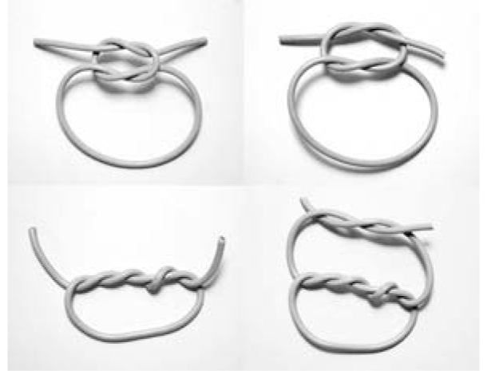

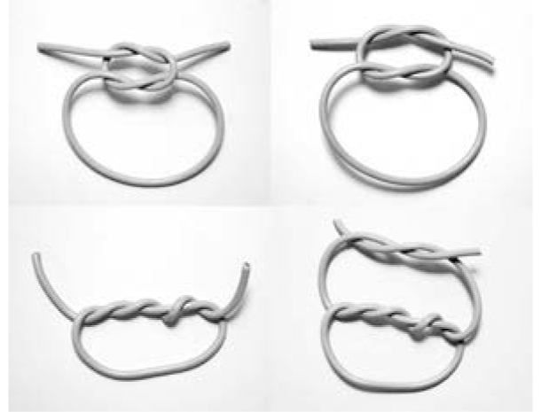

在18世纪和19世纪，范德蒙、高斯和其他一些数学家想出了如何用数学的方式来看待绳结，这样他们就可以用逻辑规则来研究绳结了。  
这个方式就是，想象把一根绳子的两端粘在一起，使其成为一个封闭的环。虽然这样一来，绳结没有胶水就做不成了，但这也让数学家能更方便地研究它。每一个绳结都可以用三维空间里的一个环来表示。在拓扑学里，研究这种问题的方法有很多，对此我们稍后会加以讨论。总之，这样一来，我们不但可以对真正存在的绳结进行种种推断，还可以研究那些在宏观世界中不成立，但在微观世界的分子结构中真实存在的“结”。

In the eighteenth and nineteenth centuries Vandermonde, Gauss and others worked out how to think of knots mathematically, so that they could be studied using the rules of logic. The idea is to imagine sticking together the two ends of the piece of string so that becomes a closed loop. This makes the knots impossible to create without glue, but much easier to reason with mathematically. Each one can be expressed as a circle that has been mapped to three-dimensional space. There are many techniques for studying this kind of thing in the field of *topology*, which we’ll come back to later. Not only can we then deduce things about real knots in string, but also about the apparently impossible ones arise in nature in molecular structures.

关于将“真实”世界中的事物转化为“数学”世界中的事物，几何图形是另一个更为古老的例子。  
数学的发展可以说经历了以下几个阶段：

Geometric shapes are another, much older example of this process of turning something from the “real” world into something in the “mathematical” world. We can think of math as developing in the following stages:

1. 它起源于对数字的研究。

1. It started as the study of numbers.

2. 人们想出了一些方法来研究这些数字。

2. Techniques were developed to study those numbers.

3. 人们意识到，这些方法也可以用来研究其他事物。

3. People started realizing that those techniques could be used to study other things.

4. 人们四处寻找其他可以用这些方法来研究的事物。

4. People went round looking for other things that could be studied like this.

其实还有一个步骤0，位于数字诞生以前：有人发明了数字这个概念。数字可以说是数学中可以研究的最基本的东西，但数字并不是一开始就有的。也许，数字的发明就是最早的抽象化过程。

Actually, there’s a step 0, before the study of numbers: someone had to come up with the idea of numbers in the first place. We think of them as the most basic things you can study in math, but there was a time before numbers. Perhaps the invention of numbers was the first-ever process of abstraction.

接下来我要讲的故事是关于抽象的数学的。我想说的是，它的力量和美丽并非体现在它所提供的答案和它所解决的问题上，而在于它对人的启蒙，它带来的照亮世界的一束光。正是这束光让人看得更加清楚，而由此，我们便迈出了认识周围世界的第一步。

The story I’m going to tell is about abstract mathematics. I’m going to argue that its power and beauty lie not in the answers it provides or the problems it solves, but in the *light* that it sheds. That light enables us to see clearly, and that is the first step to understanding the world around us.

† 数学上的推广，并不是随意对事物做出概括性断言的那种“推广”；我们稍后会谈到这一区别。

† Mathematical generalization isn’t the same as the kind where you go round making sweeping statements about things, but we’ll come to that later.

## 2 抽象Chapter 2 Abstraction

### 蛋黄酱或荷兰酱Mayonnaise or Hollandaise Sauce

#### 配料Ingredients

2 个蛋黄

2 egg yolks

调味料

Seasoning

#### 做法Method

1. 用手动打蛋器或手持式搅拌棒，将蛋黄与调味料搅打均匀。

1. Whisk the egg yolks and seasoning using a hand whisk or immersion blender.

2. 一边继续搅打，一边极其缓慢地滴入橄榄油。

2. Drip the olive oil in very slowly while continuing to whisk.

在一定程度上，蛋黄酱和荷兰酱是一样的——它们的制作方法一样，只是加入蛋黄液的油脂类型不同。在两种制作过程中，蛋黄都发挥了奇妙的魔力，使得成品变得香浓滑腻。成品逐渐成形的过程就像魔法，我怎么看都看不厌。

At some level mayonnaise and hollandaise sauce are the same—they use the same method, but with a different type of fat incorporated into the egg yolk. In both cases, the amazing near-magic properties of egg yolks create something rich and unctuous. It looks so much like magic, I never tire of watching it happen.

蛋黄酱和荷兰酱的相似之处就是数学寻找的那类事物：一些大体相似，只有微小细节不同的事物。这是一种省力的做法，因为你可以一次性学会做几件事。烹饪书也许会告诉你，制作荷兰酱需要使用一种不同的方法，但我总是置之不理，以便让我的生活更简单一些。数学也是如此，通过寻找除了微小细节外其他大体一致的事物来达成简化的目的。

The similarity between mayonnaise and hollandaise sauce is the sort of thing that mathematics goes round looking for—situations where things are somehow the same apart from some small detail. This is a way of saving effort, so that you can understand how to do both things at once. Books might tell you that hollandaise sauce needs to be done differently, but I ignore them to make my life simpler. Math is also there to make things simpler, by finding things that look the same if you ignore some small details.

### 派Pie

#### 抽象作为蓝图Abstractions as Blueprints

农舍派、牧羊人派和渔夫派三者大同小异，唯一的不同就是土豆泥下面的馅料。各类奶酥也是如此，做不同的奶酥并不需要不同的食谱，你只消学会做奶酥皮，然后把你喜欢的水果放进模具作为馅料，再把奶酥皮放在上面一起烘焙即可。

Cottage pie, shepherd’s pie, and fisherman’s pie are all more or less the same—the only difference is the filling that is sitting underneath the mashed potato topping. Fruit crisp is also very similar—you don’t really need a different recipe for different types of crisp, you just need to know how to make the topping. Then you put the fruit of your choice in a dish, add the topping, and bake it.

我的另一个最爱是倒置蛋糕。在烘焙倒置蛋糕的时候，你需要把水果放在模具底层，再把蛋糕预拌粉倒在上面，烤好以后把蛋糕整个倒过来，这样水果就在上面了。为了让蛋糕更美味，你也可以在放水果前在模具底层涂上一层加了红糖的融化的黄油，这样你就能为水果蛋糕增添一丝焦糖风味了。当然，一些水果比另一些水果更适合这种做法，比如香蕉、苹果、梨和李子。葡萄不是很适合。西瓜则完全不适合。对奶酥来说也是如此。西瓜奶酥？还是算了吧。

Another favorite of mine is upside-down cake. You put the fruit in the bottom of the cake pan, pour the cake batter on top, and after baking it you turn it out upside-down so that the fruit is on top. For extra effect you can put melted butter and brown sugar on the bottom of the cake tin first, to caramelize the fruit a bit. Of course, this works better with some fruit than others: bananas, apples, pears, and plums work well, grapes less well. Watermelon would be terrible. The same is true for crisp. Watermelon crisp? Probably not.

咸味派的制作方法也差不多。先烤好空的饼皮，放进你喜欢的馅料，再放进搅拌好的鸡蛋和牛奶（或奶油），整个放进烤箱烤制一下——完成。馅料可以是奶酪培根、鱼、蔬菜，任何你喜欢放的食材。

Savory tarts and quiches also follow a general pattern. You bake an empty pastry shell, put in some filling of your choice, and then top it up with a mixture of egg and milk or cream before baking it again. The filling could be bacon and cheese, or fish, or vegetables—whatever you feel like.

上述所有的“食谱”都并非真正完整的食谱，只是蓝图或框架。你可以加入你自己选择的水果、肉类或其他馅料来制作不同的成品，当然，你需要从那些适合做馅料的食物里选择。

In all these cases the “recipe” is not a full recipe but a blueprint. You can insert your own choice of fruit, meat, or other fillings to make your own variations, within reason.

数学也是如此。数学致力于寻找事物的相似之处，由此，对于很多不同的情况，你只需要一个“食谱”就可以应付了。关键在于你要先忽略一些细节，让事物变得更容易理解，在这之后，你可以考虑重新加入额外的变量。这就是抽象化的过程。

This is also how math works. The idea of math is to look for similarities between things so that you only need one “recipe” for many different situations. The key is that when you ignore some details, the situations become easier to understand, and you can fill in the variables later. This is the process of abstraction.

就像西瓜奶酥一样，当你提取出那份经过抽象化的“食谱”之后，你可能会发现它并不能应用于所有的“食材”。但至少你可以用它进行各种尝试，而且有些时候，看起来完全不相干的事物也可能适用于同一份食谱。

As with the watermelon crisp, once you’ve made the abstract “recipe” you will find that you won’t be able to apply it to *everything*. But you are at least in a position to try, and sometimes surprising things turn out to work in the same recipe.

思考一下等边三角形的对称：  
等边三角形既是轴对称图形，也是旋转对称图形。那么，除了把三角形剪下来折一折、转一转以外，我们还有别的方法可以描述它的对称性吗？

Think about the symmetry of an equilateral triangle. It has two types of symmetry: reflectional and rotational. How can we describe the different symmetries without cutting out the triangle and folding it up or waving it around?

有一个办法是把三个角分别标为1、2和3，如下图所示：

One way is that we could label the corners 1, 2, and 3,

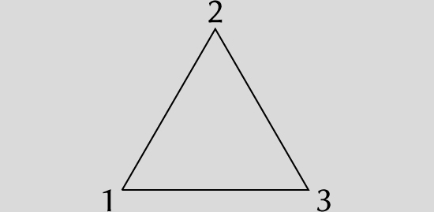

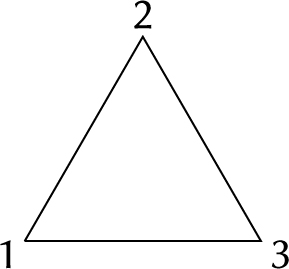

然后，我们就可以讨论这些数字可以如何交换位置了。比如，如果我们以一条中垂线为轴翻转三角形，那么数字1和3就交换了位置。如果我们把这个三角形顺时针旋转120°，那么数字1就会被转到数字2之前的位置，数字2就会被转到数字3之前的位置，数字3就会被转到数字1之前的位置。

and then just talk about how the numbers get swapped around. For example, if we reflect the triangle in a vertical line, we will swap the numbers 1 and 3. Whereas if we rotate the triangle 120° clockwise we will send 1 to where 2 was, 2 to where 3 was, and 3 to where 1 was.

你会发现，等边三角形的6种对称方式精准地对应了数字1、2和3的6种位置交换方式。等边三角形的三种轴对称，分别对应了数字1和3、1和2、2和3的换位。等边三角形的三种旋转对称则是：顺时针旋转120°后与原三角形重合，顺时针旋转240°后与原三角形重合，以及旋转360°后与原三角形重合。

You can try checking that the six symmetries of the triangle correspond exactly to the six different ways of shuffling the numbers 1, 2, and 3. There are three lines of symmetry, and they correspond to swapping 1 and 3, or 1 and 2, or 2 and 3. There are three types of rotational symmetry: 120° clockwise, 240° clockwise, and the “trivial” one where nothing moves.

该例表明，抽象上来看，一个等边三角形的对称问题与数字1、2和3的排列问题相同，因此，我们可以同时研究这两个问题。

This shows that the symmetry of an equilateral triangle is *abstractly* the same as the permutations of the numbers 1, 2, and 3, and the two situations can be studied at the same time.

### 杂乱的厨房Kitchen clutter

#### 抽象就是收起你不需要的东西Abstraction as Tidying away the Things You Don’t Need

抽象就像在准备烹饪时把你暂时不需要的厨具和配料收起来，这样厨房就不会显得那么杂乱。换句话说，抽象就是把你目前不需要的想法收起来，这样你的大脑就不会那么杂乱。

Abstraction is like preparing to cook something and putting away the equipment and ingredients that you don’t need for this recipe, so that your kitchen is less cluttered. It is the process of putting away the ideas you don’t need for the present purposes, so that your *brain* is less cluttered.

你更擅长的是清理自己的厨房还是清理自己的大脑？（我个人肯定更擅长后者。）抽象是数学研究的重要的第一步。这也是一个会让你感到有些不适的步骤，因为它让你离现实远了一些。我从来不把食品加工机收起来，因为移动它很麻烦，而且我想确保在我想用的时候随时可以使用它，而不必大费周章地把它从碗橱里拿出来。也许在大脑中进行的抽象过程对你来说就与此类似。

Are you better at this in your kitchen or in your brain? (I am definitely better at it in my brain.) Abstraction is the important first step of doing mathematics. It’s also a step that can make you feel uneasy because you’re stepping away from reality a little bit. I never put my blender away because it’s such a hassle to move it, and I want to know that I can use it at any time without going through the rigmarole of getting it out of the cabinet. You might feel like that about abstraction in the brain as well.

看看下面这个问题：

Try the following problem.

我买了两张邮票，每张36便士。我一共花了多少钱？

*I buy two stamps for 36¢ each. How much does it cost?*

这就是一种抽象的过程。我们丢弃了，或者说忽略了我们要买的是邮票这件事，因为这与解题无关。邮票也可以替换为苹果、香蕉、猴子……而我们要计算的总和是一样的，解也一样：72便士。

This is a process of abstraction. We have thrown away, or ignored, the fact that the thing we are buying is *stamps*, because it doesn’t make any difference to the answer. It could be apples, bananas, monkeys. . . the equation would still be the same, and so the answer would still be the same: 72 of whatever we’re buying.

那么下面这道题呢？

What about this one:

我父亲的年龄现在是我的年龄的3倍，10年以后，他的年龄将会是我的年龄的2倍。那么，我现在的年龄是多少岁？

*My father is three times as old as I am now but in ten years’ time he will be twice as old as me. How old am I?*

或者这道题：

Or this one:

我有一个6英寸蛋糕的食谱，其中写明了覆盖蛋糕的顶部和侧面总共需要用到多少克糖霜。那么，覆盖一个8英寸蛋糕的顶部和侧面需要用到多少克糖霜呢？

*I have a recipe for frosting the top and sides of a 6-inch cake. How much frosting do I need for the top and sides of an 8-inch cake?*

对于那道关于邮票的题目，你大概不需要写下计算过程就可以得出结果，因为答案非常显而易见。但要解答后面两个问题，你可能就需要进行一些抽象化的工作，你需要忽略诸如父亲、蛋糕、糖霜这些细节，写下包含数字和符号的计算式。在本章的后面部分，我们会揭晓这两道题的答案。

For the question about stamps you probably didn’t need to write down an equation, because the answer was immediately obvious to you. However for these last two questions perhaps you would need to perform some abstraction to work out the answer, where you throw away the fact that you’re talking about your father, or a cake and frosting, and write down some arithmetic, with numbers and symbols. We’ll see what arithmetic we get from these word problems a bit later in this chapter.

### 曲奇饼干Cookies

#### 太真实的事物不遵循数学规律How Things That Are Too Real Don’t Obey Mathematics

如果你曾经试过教小朋友学算数，你可能用过如下这个例子。你试着让他们解决这个实际生活中的问题：

If you’ve ever tried teaching arithmetic to small children, you might have come up with the following problem. You try and get them to think about a real-life situation such as:

如果奶奶给你五块曲奇饼干，爷爷又给你五块曲奇饼干，你一共有几块？

*If Grandma gives you five cookies and Grandpa gives you five cookies, how many cookies will you have?*

孩子回答：“一个也没有，因为我会把它们全吃掉！”

And the child answers: “None, because I’ll eat them all!”

这里的问题在于，糖并不遵从逻辑规则，所以用数学来研究它们不管用。我们可以强迫糖遵从逻辑吗？比如，我们可以给这个例子增加一条额外的规定：“……并且你不能吃这些糖。”但如果不让孩子吃糖，那么糖的意义何在？我们可以把糖视为某种“东西”而不再是糖。我们丢掉了一些现实性的细节，却获得了新的视角和更高的处理效率。数字的好处在于，我们可以研究“东西”，并且不必因为“东西”自身属性的不同而改变我们的思考路径。一旦我们明白2+2=4，我们就知道了两个东西加上另外两个东西会变成四个东西，不管这些东西是糖、猴子、房子还是别的什么。这就是抽象的过程：把糖、猴子、房子或别的什么，变成数字。

The trouble here is that cookies do not obey the rules of logic, so using math to study them doesn’t quite work. Can we force cookies to obey logic? We could impose an extra rule on the situation by adding “. . . and you’re not allowed to eat the cookies.” If you’re not allowed to eat them, what’s the point of them being cookies? We could treat the cookies as just *things* rather than cookies. We lose some resemblance to reality, but we gain scope and with it efficiency. The point of numbers is that we can reason about “things” without having to change the reasoning depending on what “thing” we are thinking about. Once we know that 2 + 2 = 4 we know that two things and another two things make four things, whether they are cookies, monkeys, houses, or anything else. That is the process of abstraction: going from cookies, monkeys, houses, or whatever, to numbers.

数字是如此的基本，我们很难想象没有它们的生活，也很难想象发明它们的过程。当我们数数的时候，我们甚至都没意识到自己已经在使用抽象思维了。看小孩子们努力地学算数会让你更容易意识到这件事，因为孩子们尚未适应这一从具体到抽象的跨越。

Numbers are so fundamental, it’s difficult to imagine life without them, and difficult to imagine the process of inventing them. We don’t even notice that we’re making a leap of abstraction when we count things. It’s much more noticeable if you watch small children struggling to do it, because they’re not yet used to making that leap.

### 点兵点将Eeny Meeny Miny Moe

#### 数字作为一种抽象形式Numbers as an Abstraction

我曾经在一所小学里帮忙教课，在那里，我认识了一位精力充沛的孩子妈妈。她也在那所学校帮忙。她告诉我，当别的妈妈骄傲地宣称她们的孩子可以数到20或30时，她会感觉很沮丧。但她会立即这样反驳：“我儿子只能数到3，但他明白3到底是什么意思。”

I remember a wonderfully feisty mother at an elementary school I was helping at. She remarked on how frustrating it was when other mothers competitively declared that *their* child could count up to 20 or 30. “My son can count up to three,” she said defiantly, “But he knows what three *is*.”

她说的有道理。  
当一个孩子刚开始“学着数到10”的时候，他们所做的不过是学着背一首小诗，像是“小小蜘蛛儿，爬上排水管……”一般。只不过，这首小诗是这样写的：  
之后他们会意识到，这首诗和指东西有关，于是他们便开始随意地一边指东西，一边背这首“诗”。

And she had a point. When children first “learn to count to ten” they aren’t really doing more than learning to recite a little poem, like “The itsy-bitsy spider climbed up the water spout. . . .” It just so happens that the “poem” goes:

“一、二、三、四、五、六……”

*“One, two, three, four, five, six, . . .”*

再然后，他们意识到他们应该在背这首诗的时候，每念一个字，就指着一样东西，但他们很难确保每样东西只被指过一次。所以当大人问“这幅图里有几只鸭子”的时候，他们每次的回答都会不同。他们也可能会认定某一个数字，比如6，然后把所有东西都数成6个，也不管鸭子到底有几只。

Then they learn that this has something to do with pointing at things, so they start pointing while reciting the “poem,” a bit haphazardly. Only later do they learn that they’re supposed to point at one thing per word in the poem, but they have trouble making sure they have only pointed at each thing once, so they will get rather variable answers if you ask them, “How many ducks are in this picture?” Or they might latch on to a particular number—say, six—and somehow manage to count everything as being six, no matter how many ducks there really are.

最后，他们意识到他们要把这首诗里的每一个字都精准地对应上一样东西，一字一物，不多不少。直到此时，他们才真正学会数数。这就是一种抽象化的过程，而且是一种出奇深奥的抽象化过程。

Finally they’ll get the idea that they’re supposed to match up the items rather precisely with the words in the poem, one item per word, no more and no less. That is when they *really* know how to count. This is a process of abstraction, and a surprisingly profound one.

试想一下做买卖但不会数数的情景。“嘿，你的每一只羊，我都用一袋谷子来交换。”然后你就得去把谷子和羊群一一对应排列在一起，以确保每只羊确实都换到了一袋谷子。后来你发现，在面对一群羊和好几袋谷子的时候，一边指着羊或谷子一边有韵律地背一首小诗会更方便。这首诗可以是关于任何内容的，只要你在指着羊和谷子的时候背的是同样的诗即可。它甚至可以是“点兵点将”（“Eeny meeny miny moe”）这样毫无意义的诗。

Imagine trying to engage in trade without knowing how to count. “Hey, I’ll trade you one sack of grain for each of your sheep,” you say, and then you go and line up sacks of grain against sheep to make sure you really have one per sheep. Then you work out that it’s more practical to recite a little poem while pointing at the sheep in rhythm, and do the same thing with the sacks of grain. The poem could be anything as long as you recite it exactly the same way for the sheep and for the grain. It could be “Eeny meeny miny moe.”

最后，你创作了一首各方面都很合适的诗，并在每次做买卖的时候都坚持使用这首诗，一劳永逸地解决了所有的问题。于是突然间，你创造了数字。这就是我们在“学习数数”的过程中不曾留意的抽象化过程。由此我们也知道了，简单地学习背诵“1、2、3、4……”这首诗与理解如何用它来数数是截然不同的两件事。

Finally you make up a poem once and for all to use for all your trades, and you stick to it. And suddenly you’ve invented numbers. That is the process of abstraction that we don’t even notice when we learn to count. So we see that there is a crucial difference between simply learning the poem “One, two, three, four. . .” and understanding how to use it.

### 婴儿和洗澡水The Baby and the Bathwater

#### 小心别扔掉太多Being Careful Not to Throw Away Too Much

每个人都知道，婴儿和洗澡水不能一起倒掉。当我们到处简化和理想化我们的问题情境时，我们必须很小心地避免过度简化——我们不能把研究对象简化到让它们失去了其所有有用的特性。比如，当我们在搭乐高积木时，我们可以忽略它们的颜色，但我们不能忽略它们的大小，因为积木的大小会影响我们具体要怎么搭。但如果我们只是用乐高积木来数数，那么尺寸就是可以忽略的。

It is important, as everyone knows, not to throw the baby out with the bathwater. When we go round simplifying or idealizing our situations, we must be careful not to *oversimplify*—we must not simplify our objects to the point that they’ve lost *all* of their useful characteristics. If we’re thinking about stacking Lego blocks, for example, we can ignore what color they are, but we shouldn’t ignore what size they are, as that affects how we can stack them. But in another situation we might be using Lego bricks merely as counting blocks, in which case we can ignore their size as well.

决定忽略哪些特点主要取决于我们讨论的情境。这个重要的话题我们之后会再来探讨。对于范畴论而言，情境非常重要。

Choosing what features to ignore should depend heavily on what context we’re thinking about. This is a theme that will come back importantly later. Category theory brings context to the forefront.

而得到这一结果后，你还要进一步考虑具体的情境：你不可能租0.7辆小巴，所以为了将所有人包括在内，你需要将结果“五入”为7辆小巴。

But then you have to take the context into account: you can’t book 0.7 of a minibus, so you have to round up to 7 minibuses.

你得到了同样的结果，但这次的情境与上一次不同：你不可能寄0.7块巧克力，所以为了不超出预算，你需要将结果“四舍”为6块巧克力。

But this time the context gives a different answer: since you can’t send 0.7 of a chocolate, you’ll need to round *down* to 6 chocolates.

### 心碎Heartbreak

#### 抽象作为简化Abstraction as Simplification

曾经，在经历了一次令我心碎的悲惨事件后，我好心的朋友们为了能更好地“理解”我，开始不断地询问我各种关于此事的细节，而这一举动只让我感到越来越厌烦。最后，一个聪慧的朋友对我说：“其实这件事很简单。你失去了你所爱的某样东西。”这就是任何人需要知道的关于此事的情况。然后，她成功地将我的注意力转移到探讨将事物简单化而非复杂化是一项多么明智的行动，即便有些人会觉得这样做让你看起来很蠢。“简单化”和“过度简化”有一个微妙的差别：后者意味着你想错了，而且忽略了重要的问题。

After one major episode of heartbreak I was getting tired of well-meaning friends asking me for more and more details of exactly what happened, in an attempt to “understand” it. Finally one wise friend said to me, “It’s very simple, really. You’ve lost something you loved.” That was all anyone needed to know of the situation. She then successfully distracted me into a long discussion about how it’s really more intelligent to be able to simplify things than to complicate them, even if some people think it makes you look stupid. There’s a subtle difference between something that’s “simple” and something that’s “simplistic”; the latter indicates that you’ve missed the point and ignored a complication that is crucial.

那位朋友的智慧就是一种抽象，她将心碎的本质提炼出来了。看上去，抽象好像会带着你逐步远离现实，但实际上，它会带领你逐步贴近事物的本质或核心。要抵达核心，你就必须剥离衣服、皮肉和骨头。

My friend’s wisdom was a type of abstraction, abstracting heartbreak down to its very essence. Abstraction can appear to take you further and further away from reality, but really you’re getting closer and closer to the heart of the matter. To get to the heart, you have to strip away clothes and skin and flesh and bone.

### 路标Road Signs

#### 抽象作为对事物理想模式的研究Abstraction as the Study of Ideal Versions of Things

路标也是一种抽象形式。它们并不会为你细致地描绘路途中可能出现的各种情境，而是会描绘一种理想化的情境，并凸显该情境的核心特征。比如，不是所有的弓形桥都长成下面这样：

Road signs are a form of abstraction. They don’t precisely depict what is going on in the road but represent some idealized form of it, where just the essence is captured. Not every humpbacked bridge looks exactly like this:†

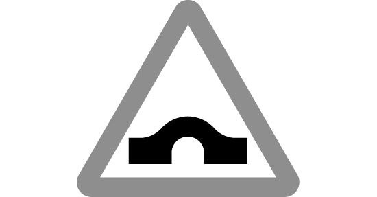

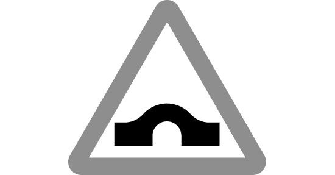

但这个路标概括出了弓形桥的本质特征。同理，不是所有过马路的孩子都长成下面这样：

but this captures the essence of humpbacked-bridge-ness. Similarly, not all children crossing the road look exactly like this:

[figure not shown]

[figure not shown]

但此类简化的优点是显而易见的。当你在开车的时候，看懂路标比读懂一句话要快得多；而且，路标也能让不熟悉当地语言的外国人更容易理解。而路标的缺点是，在你刚开始学习开车的时候，你必须先弄懂种种稀奇古怪的路标都是什么意思。总有一些路标要比另一些路标更容易看懂。比如下图左边这种就比右边这种贴近现实许多：

Nevertheless, the benefits of this system are clear. It’s much quicker to take in a symbol than read some words while you are driving. Also it’s much easier for foreigners to understand. The disadvantage is that when you first start driving you have to learn what all these funny symbols mean. Some of them, such as this one,

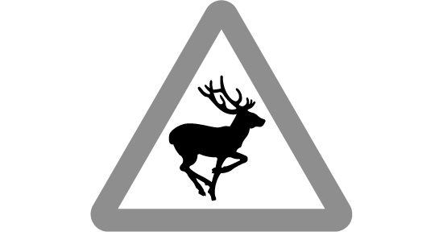

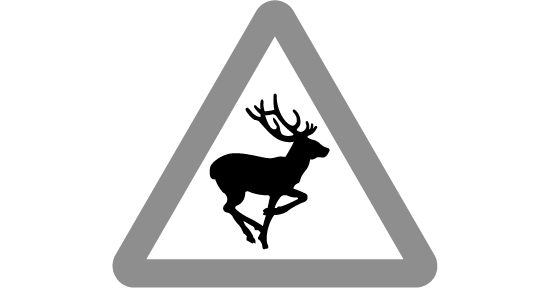

比另外一些路标更接近现实，比如下面这个：

are much closer to reality than others, like this:

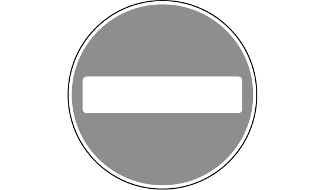

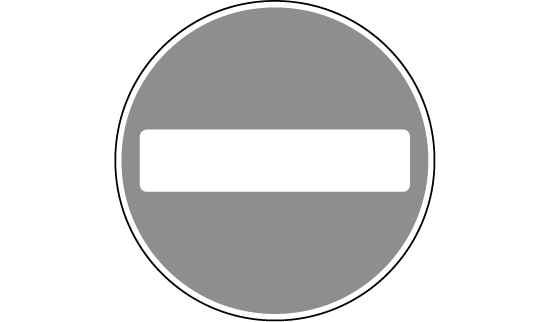

上图右边这个“禁止入内”的路标就非常抽象。它看起来完全不像它所代表的意思。（“禁止入内”看起来应该像什么样子呢？）但在现实生活中，它的作用更重要——你在你的驾驶生涯中遇到的“禁止入内”的路标想必要远多于“有鹿出没”的路标。

This “No entry” sign is entirely abstract: it doesn’t look like the thing it is representing at all. (What does “No entry” look like?) But it’s also more important—you will probably encounter more of those in your driving life than the one warning you there might be deer crossing the road.

数学的抽象化过程的弊端之一就是，你需要用到一大堆稀奇古怪的符号。其原因与上述情况类似：一旦你明白了这些符号的意思，它们使用起来就会变得很方便，从而你可以将更多的脑力集中用于攻克更为复杂和重要的数学问题。符号的使用也使数学可以跨越语言——你可能会惊讶地发现，读一本用某种你不懂的外语写成的数学书并没有那么困难。

One side effect of the abstraction of math is that a variety of funny symbols gets used as well, for the same sorts of reasons: once you know what they mean, the symbols are much quicker to take in, and you can reserve your mathematical brainpower for the more complicated parts of the math you’re supposed to be focusing on. It also makes the math easier to understand across different languages—it’s surprisingly easy to read a math book in a language you don’t know.

而不必读“二加二等于四”。随着数学越来越复杂，符号也会越来越复杂，例如：

than “two plus two equals four.” As math gets more and more complicated, the symbols get more and more complicated as well, with things like

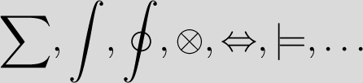

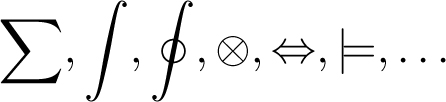

我不打算解释这些复杂符号的意义，我只是想举个例子。就像路标一样，以符号为主要语言的数学一开始看上去的确很难理解，但长远来看，符号起到了重要的简化作用。

I’m not going to explain what the more esoteric symbols mean here—this is just to give an idea of some of the symbols that get used. As with road signs, they make math look a bit incomprehensible at first, but they make it easier in the long run.

### 谷歌地图Google Maps

#### 用地图指导现实的困难The Difficulty of Relating the Map to the Reality

读懂地图为什么不容易？看懂地图不难，难的是将地图与实际路况一一对应，让地图发挥效用。地图是对现实的抽象，它选择了现实的某些方面进行描述，为的是让你更容易找到你要找的地方。在实际应用中，困难存在于抽象与现实之间的转化，也就是在地图和你要找的地方之间建立联系。

What’s difficult about reading a map? It’s not the actual reading of the map that’s hard, but matching that up with reality in order to put the map to practical use. A map is an abstraction of reality. It depicts certain aspects of reality that are supposed to help you find your way around. The difficulty, in practice, is in translating between the abstraction and the reality—that is, making the link between the map and the place you’re actually trying to find your way around.

谷歌地图提供了一种将抽象转化为现实的便捷之路，它是通过谷歌街景和全球定位系统实现的。通常，在地图使用中，最难弄明白的是：  
你在哪里？  
你面朝什么方向？  
这两点是地图和现实之间的重要连接点。全球定位系统能帮你弄清楚你在哪里，而谷歌街景则能为你提供一张关于你所在之地的现实场景照片，让你弄清楚自己面朝什么方向。

Google maps gives us a brilliant way of moving from the abstract to the concrete, via Street View, and GPS. Often the hardest part about using a map is working out (a) where you are in the first place, and (b) which way you’re facing. Those are the crucial pivot points between the map and the reality. GPS has sorted out the business of working out where you are, and Street View has sorted out the business of which way you’re facing by giving us a very realistic representation of reality in the form of an actual picture of it.

数学也必须经由这几个步骤来实现。首先，你需要提炼现实。然后，你需要在抽象的世界进行逻辑推理。最后，你需要把这些抽象的东西再应用到现实中去。不同的人擅长这个过程中的不同步骤。整个过程最核心的部分就是游刃有余地在抽象和现实之间穿梭，而要做到这一点，就必须先有人来画一张地图。

Math has to go through these steps as well. First you have to turn the reality into an abstraction. Then you do your logical reasoning in the abstract world. Then finally you have to turn that back into reality again. Different people are good at different parts of this process. But really the key part is being able to move back and forth between the abstract and the real. Still, *someone had to draw the map*.

现在，我们需要进行逻辑推理，用代数运算来确定d是多少。（就整个问题解决过程而言，只有这一步涉及真正的数学。）

Now we actually do the logical reasoning, manipulating the algebra to find out what the diameter *d* needs to be. This is the only part that’s actually math.

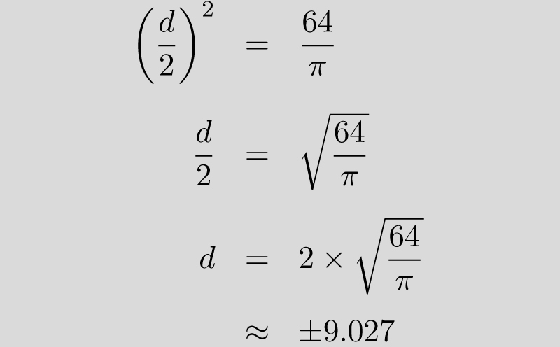

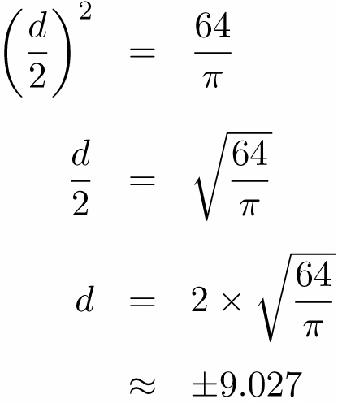

最后，我们需要把得到的结果应用到现实中去。首先，我们不需要那个负数解，因为我们在讨论的是蛋糕模具，所以解必须是正数。其次，我们不需要那么多小数点，因为蛋糕模具的尺寸通常是用整数来表示的。综上所述，我们需要的那个现实答案是9英寸的圆形蛋糕模具。

Finally we take the context into account and turn this back into reality. First of all, we don’t want the negative answer because we’re talking about cake pans here, so the answer needs to be a positive number. Secondly, we don’t need all those decimal places—cake tins are usually only measured to the nearest inch. So the answer in reality is that we need a 9-inch round pan for our cake.

数学以及使用地图的关键就在于针对不同情境进行不同程度的抽象。当你在看某条街的地图时，你需要地图显示出这条街上所有楼房的照片吗？你需要知道哪里有草地，而哪里没有吗？答案取决于你准备用地图来做什么，对于不同的情况，你需要的地图也不一样。如果你在开车，你就需要知道哪些路是单行道，但如果你在步行，这条信息就不重要了。在数学里也是如此，不同的情境需要不同程度的抽象。

The key in math, and with maps, is to find the most appropriate level of abstraction for the given moment. Do you need little pictures of all the buildings on a street when you’re looking at a street map? Do you need to know where there is grass and where there isn’t? It depends on what you’re using the map for, and you’ll need different maps for different situations. If you’re driving, then you’ll want to know which streets are one-way, but that’s not very relevant if you’re on foot. The same is true of math. There are different levels of abstraction available for different situations.

数字1是什么？回答这个问题有两种方法，它们分别是两种不同程度的抽象。

What is the number 1? Here are two different ways of answering that question, at different levels of abstraction.

第一个回答：1是数数的基本单元。

First answer: 1 is the basic building block of counting.

第二个回答：1是唯一一个其他数字乘以它之后不会发生变化的数字。

Second answer: 1 is the only number with the property that multiplying by it does nothing.

这两个答案在不同的情境下都是有意义的。当我们需要做加法的时候，第一个答案就很有用；在数学里，这个答案相当于将数字定义为一个“群”——一个我们可以做加法的世界。而当我们想讨论乘法的时候，第二个概念就很有用了；这个答案相当于将数字定义为一个“环”——一个我们既可以做加法也可以做乘法的世界。关于群的研究与图形的对称性相关，关于环的研究与图形的其他几何学特性有关。我们稍后会继续讨论这个问题。

Each of these answers is useful in different contexts. The first is for when we are most interested in adding numbers up; this characterizes numbers as something called a “group”—a world in which we can do addition. The second is for when we are also interested in multiplying; this characterizes numbers as something called a “ring”—a world in which we can do addition *and* multiplication. The study of groups is related to the symmetry of shapes, and the study of rings is related to other aspects of the geometry of shapes. We’ll come back to this later.

不合适的地图会让人沮丧，因为它们不是太具体就是太不具体。（比如，我就不喜欢那些会显示楼房三维照片的地图，它们太过具体，会阻碍人们分辨街道的走向。）

If you use an inappropriate map for the situation you’re in, you’ll get frustrated, whether it’s too realistic or not realistic enough. (I dislike those street maps with pictures of buildings in three dimensions, so that they actually obscure the lines telling you where the street goes.)

在数学中也是如此。如果你把某种过于复杂的数学概念或方法应用到一个并不真正需要它的情境中，你就会觉得这种数学概念或方法毫无意义。这就好比用杜威十进制分类法来给你仅有的20本书归类一样。

The same is true of math—if you try and use complicated math for a situation that doesn’t call for it, you’ll think the math is pointless. It’s a bit like using the Dewey decimal system if you only own twenty books.

### 跳高High Jump

#### 抽象的跳高Leaps of Abstraction

我上学的时候很不擅长跳高。当然，我早就说过自己不擅长各种运动，但跳高是我尤其不擅长的一项，我甚至跳不过最矮的那根杆。问题是，没有人教我怎么才能跳过最矮的那根杆。我记得班上的一部分同学好像天生就会跳，而其他不会跳的人则被告知再试一次，再试一次，再试一次。但是当你在众人面前反复几次碰掉横杆的时候，你会忍不住失去希望并放弃尝试。

I was terrible at the high jump in high school. I already said I was terrible at all sports, but with the high jump I failed before I started—I couldn’t jump over the bar even at its lowest. The trouble is that nobody tried to teach me what I needed to do to get myself over that bar. Other people in my class just seemed to be able to do it, as if by magic, and the rest of us were simply told to do it again. And again. And again. There are only so many times you can knock down a high jump bar, with an audience, without feeling disillusioned and eager to give up.

思考越来越抽象的概念与跳高多少有些类似。你必须跳过被放置得越来越高的横杆。而如果在最开始没有人给你解释如何才能跳过去的话，你就会一直碰掉横杆，直至放弃尝试。不同的人会在不同的“高度”达到自己的抽象极限，就像在跳高中，横杆每提高一次就会有一部分人失败退出。

Thinking about more and more abstract concepts is a bit like the high jump. You have to get yourself over a progressively higher and higher bar, and if nobody explains how to do it, you will keep knocking the bar off and want to give up. Different people reach their limit of abstraction at different moments and, just as with the high jump, people drop out at each round.

从具体事物到数字的抽象对许多人来说并不困难，他们甚至都没有意识到自己进行了这样的抽象转换。让不少人觉得难以逾越的第一道横杆很可能是从数字到变量x 和y的转换。他们不会进行这种转换，也不理解这种转换的意义，因此他们在数次失败的尝试后选择了放弃。（就像我始终不理解跳高的意义一样。但现在，我明白了背越式跳高是一种能使你的身体以一种优雅的姿态越过横杆的有效方式。如果当时有人告诉我，完成一次跳高甚至不需要让你的身体重心越过横杆，我应该会对跳高更感兴趣。）

Most people are able to make the abstraction from *objects* to *numbers* and don’t even notice that is a process of abstraction at all. One popular moment where many people find they can’t get over the bar any more is where the numbers turn into *x*’s and *y*’s. They can’t do it, and they also can’t see the point of doing it, so they get disillusioned and give up. (I never saw the point of the high jump either, but now I see that the Fosbury flop is a satisfyingly elegant way of getting your body over a bar as efficiently as possible. If someone had explained to me back then that your center of gravity *doesn’t even have to go over the bar,* I’d have been much more interested.)

另一个很多人在学习数学的过程中会遇到的瓶颈是微积分——一种全新的、奇怪的，甚至可以说是狡猾的运算和推理“无穷小”的事物的方法。一部分人通过了严格微积分的考试，但仍然不幸在数学本科阶段或博士阶段遇到了瓶颈。

Another popular moment where people reach their abstract limit is calculus, which involves a completely new and strange—and, frankly, a bit sneaky—way of manipulating and reasoning with “infinitesimally small” things. Some people get through rigorous calculus but unfortunately reach their limit half way through their undergraduate math degree, or in the middle of their PhD.

大多数人只会在大学的数学课上学到严格微积分。人们认为它难，是因为它不符合人们通常所理解的数学——确切地描述及阐释事物并给出高度确定性的答案。

Rigorous calculus is something most people only meet if they do math in college. People find it hard because it doesn’t fit with their idea of what mathematics is—pinning things down and getting answers to things with great certainty.

中学里的微积分通常会用于解决某些具体问题，比如：“如果你画出了y=x2的函数图像，那么x=0到x=2之间曲线下阴影部分的面积是多少？”

Calculus in high school usually consists of answering specific questions such as “If you draw the graph of *y* = *x*<sup>2</sup> and shade in the space under the curve from *x* = 0 up to *x* = 2, what is the area that you have filled in?”

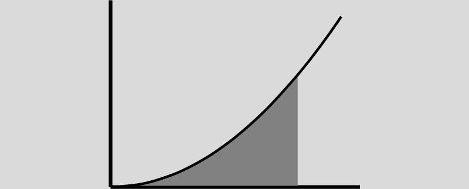

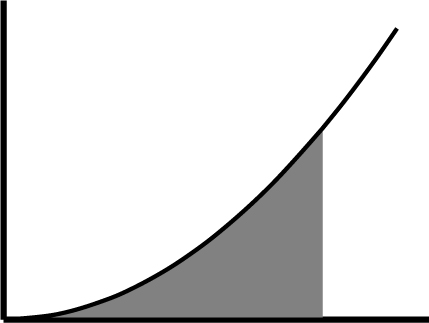

在中学里，老师会教我们这样求解：“对x2进行积分后得到x3/3，然后代入x=2，得出解为8/3。”

但在大学里，我们需要做的是证明这个计算过程的有效性。在中学，我们通常会用一种实验性的方法给出证明，即在小方格纸上画出函数图，再数一数阴影部分有多少个小方格。因为总会有一些小方格没有被阴影填满，所以只有当小方格无穷小的时候，我们才能得出真正精确的答案。

In college we actually prove that this argument is valid. In high school you might see it justified somewhat experimentally, by drawing the curve on graph paper and then counting the squares under the line. Some of the squares will only be partial squares, so you will only get a truly accurate answer if you use infinitesimally small squares. But these don’t exist.

严格微积分将计算阴影面积的论证过程纳入滴水不漏的逻辑分析，这反而让人们更加困惑，因为它没有以人们期待的那种方式给出一个确切的答案。相反，它给出的回答是：画着无穷小的小方格的纸是不存在的，因此当我们用方格越来越小的纸画函数图时，我们会发现阴影面积的数值越来越接近8/3。进而我们可以证明，无论我们希望这个数值有多接近8/3，总有一个尺寸的小方格可以满足我们的要求。

资深的数学学者可能会遇到的一个抽象瓶颈则是范畴论。他们遇到这个困难时的反应就和中学生遇到x和y时的反应一样——他们不理解为什么要这么做，并且拒绝进一步的抽象。每到这时，我就会想起约翰·拜艾茲（John Baez）教授在国际范畴论论坛上谈到抽象时提出的观点：

A moment where advanced mathematicians sometimes reach their abstract limit is category theory. They react in much the same way that teenagers do when they meet *x*’s and *y*’s—they say they don’t see the point, and resist any further abstraction. I am always reminded of Prof. John Baez, who said the following during an argument about abstraction on the worldwide category theory email list:

如果你不喜欢抽象，那你为什么还要研究数学呢？也许你该去金融行业，毕竟，那里所有的数字前面都有一个美元符号。

*If you do not like abstraction, why are you in mathematics? Perhaps you should be in finance, where all the numbers have dollar signs in front of them.*

目前来看，我暂时还没有遇到我无法突破的抽象瓶颈，但我仍然记得我曾遇到过的几次重大挑战，在那些时刻，我总觉得自己必须奋力一搏才能越过面前的横杆。

I haven’t yet met my abstract limit, but I do remember various key moments in my life where I was pushing a boundary and felt I had to make a conscious effort to get over the next bar.

##### 从数字到图像From Numbers to Pictures

我母亲教会了我如何画x2的函数图，就像这样：

My mother taught me how you can draw a graph of *x*<sup>2</sup> like this:

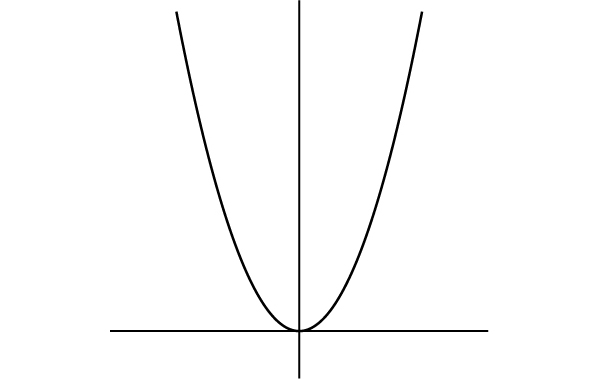

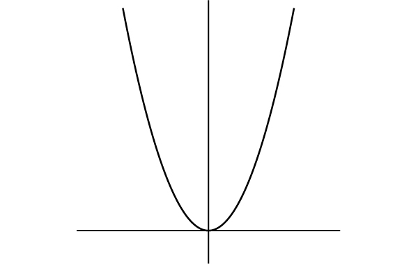

我清晰地记得自己对于数字的取平方过程竟然可以转化为一个曲线图像这件事的极度困惑。我坐在家里的绿色大扶手椅上想啊想，想到我的大脑都快要从头骨里面跳出来了。在我的记忆里，这就是我每一次在做研究时遇到一个很难理解的数学概念时的真实感受。

I distinctly remember my bafflement at the fact that you could turn the process of squaring numbers into a *picture* of a curve. I sat in our big green armchair at home thinking and thinking about this until my brain felt like it was popping out of my head. And in my memory this is the exact same feeling I’ve had every time I’ve thought about a difficult mathematical concept in my research.

##### 从数字到字母From Numbers to Letters

我知道我可以将这个方程式进行如下变换：

I knew this would turn into

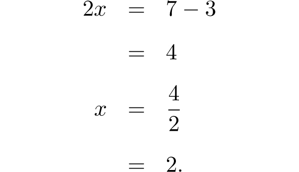

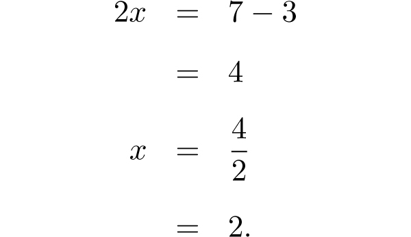

就像我总跟我的学生们说的那样，当你因为之前没有搞懂一件事而觉得自己很傻的时候，这种心情恰恰说明，你现在比当时更聪明了。

Well, as I say to my students, feeling stupid for not having understood something before just shows that you are now cleverer than you were then.

##### 从数字到关系From Numbers to Relationships

我印象中最近的一次突破抽象瓶颈，是我刚开始学习范畴论的时候。为了叙述的完整性和趣味性，我还是先来说明一下这个抽象概念是什么吧——“只包含一个对象的范畴就是幺半群”。尽管笑吧，但这就是当时让我困惑不已的那个概念。我连续几天都在思考这个概念，再一次感觉到我的大脑快从头骨里面跳出来了，仿佛回到了第一次看到曲线图像的时候。而现在，只有一个对象的范畴就是幺半群这个概念对我而言已经是一个理所当然的事实，所以我也知道，我肯定比当时更聪明了。现在就来解释这个例子的含义还为时尚早，我会在本书的第二部分探讨这个问题。

This is the last big leap of abstraction I remember having to make, and it happened when I was first learning category theory. For the sake of completeness and perhaps amusement value I’ll include here what it was: the idea that *a one-object category is exactly a monoid*. Laugh as much as you like; there it is. I sat for days thinking about it and feeling like my brain was popping out of my head, just like when I was a child and thinking about a graph for the first time in my life. And the fact that a one-object category is exactly a monoid is now so obvious to me that I know I am definitely cleverer now than I was then. It’s a bit early to explain this example now, but I’ll come back to it in the second part of the book.

我们之后会谈到，范畴论研究的是事物之间的关系，一个范畴就是一个研究这些关系的数学情境。一个幺半群也是一个数学情境，只不过其涉及的研究对象是更具体的东西，比如数字及类似事物的乘法。“只有一个对象的范畴就是幺半群”这一概念呼应了将数字看作世界与自己之间的关系的观点。我知道这听上去有些怪异，但这一理解方式对明白这个概念的含义非常重要。

We will see that category theory studies relationships between objects. A *category* is a mathematical context for studying these relationships. A *monoid* is a mathematical context for studying something much more concrete: multiplication of things like numbers. The fact that a one-object category is a monoid corresponds to viewing numbers as relationships between the world and itself. This sounds quite strange, but it is remarkably powerful.

### 下金蛋的鹅The Goose That Laid the Golden Eggs

#### 制造解决问题的机器Making Machines for Solving Problems

我们都希望找到制造金蛋的方法，但如果我们能找到直接“制造”一只下金蛋的鹅的方法，那就更好了——一个下金蛋的鹅的制造机。更进一步，如果我们能制造一个专门用来制造上面这种机器的机器，岂非更佳？一个制造下金蛋的鹅的机器的机器。这就是一种抽象：制造机器来做某件事，而不是直接去做某件事。这种做法的目的是节省人力和脑力，让人类只需要负责思考那些机器做不到的事情。

It would be lovely to find a way of making golden eggs. But it would be even better to find a way of making a goose that lays golden eggs: a goose-that-lays-golden-eggs machine. But wouldn’t it be even better to make a machine that makes these machines? A “goose-that-lays-golden-eggs machine” machine. This is a form of abstraction. It’s the idea of building a machine to do something, rather than directly doing the thing yourself. So really it’s just a form of conservation of energy, or of reserving human brainpower for the things machines can’t do.

要制造一台机器去做本来由人来做的工作，你首先需要做到在不同的层面上对这项工作有所理解。当你走在一个你很熟悉的地方时，你不会去想你正在什么街道上走路，或者在哪个路口、什么时候需要转弯，你只需要跟着自己的直觉走就好。但如果你要告诉别人该怎么走，你就需要更仔细地分析这条路你具体是怎么走的，以便解释给别人听。也许你也有过这样的经历：当你向当地人打听某条街道具体在哪里时，他们往往回答不上来，原因就在于，当你走在你自己家乡的街道上时，你并不会特地去想这些街道的名字。

In order to build a machine to do something rather than doing it yourself, you have to understand that thing at a different level. It’s like giving someone directions. When you walk somewhere you know well, you don’t really think about exactly what streets you’re walking on, or which way you’re turning and when. You probably go somewhat instinctively. But when you’re telling someone else how to get there, you have to analyze more carefully how you do it, in order to explain it. You might have noticed that if you ask a local person where a certain street is, they will often not be very sure, as you don’t really think about street names when you’re wandering around your own town.

学习外语也是如此。当你学习的是自己的母语时，你通常不会去思考它的具体使用规则——你会本能地模仿你周围的大人。而当你长大成人，某个外国人问起关于你的母语中一些让他难以理解的部分时，你就不得不回过头去以一种完全不同的方式分析自己究竟是如何使用这种语言的。

Something similar happens when learning a language. When you learn it as your mother tongue, you don’t really think about how it works—you pick it up from the adults around you instinctively. Then when you’re an adult and a foreigner asks you to explain some aspect of the language that is confusing them, you have to go back and analyze how you speak, in a way you might never have done before.

如果你想要制造一台做蛋糕的机器，你就必须把制作蛋糕的每个步骤分析得清清楚楚，这样你才能弄明白该如何让机器去完成这个任务。即便只是打鸡蛋也需要进行认真的分析——我们是怎么知道该用多大的力气把鸡蛋磕到碗上的呢？

If you’re building a machine to make a cake, you’ll have to analyze each step rather carefully in order to work out how to get a machine to do it. Even cracking an egg would require careful thought—how do we know how hard to tap the egg against the bowl?

因为其中的a、b和c可以是任意数字。

because then *a, b,* and *c* can be any numbers at all.

我们还可以试着用类似的方法得到一元二次方程的通解，即解出下面这个方程：

We can then try it for quadratic equations

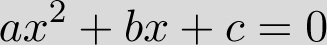

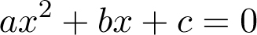

然后，我们就会得到解决此类问题的机器所给出的那个经典答案：

and we learn that the “machine” for solving these gives the famous solution

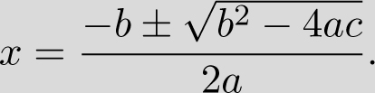

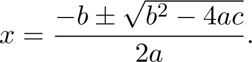

更进一步，为了发明出能制造这些解方程机器的机器，我们就需要理解“代数基本定理”（fundamental theorem of algebra）：任何一个一元复系数方程都至少有一个复数根。我们在后文中会对这个定理进行解释。

As a further level of building a machine that makes these machines, there is the *Fundamental Theorem of Algebra* which tells us that every polynomial equation has at least one solution, as long as we allow complex numbers, which we’ll come to later.

### 切蛋糕Cake Cutting

#### 一个关于抽象的例子An Example of Abstraction

我还记得第一次做英国中等教育普通证书（GCSE）资格考试的数学考试题时的一道题目。那道题是关于在给定可以切的刀数时，能把蛋糕切成最多块的方法的。很显然，如果你只能切一刀（直线），你就只能得到两块蛋糕，如果你只能切两刀，那么你最多只能得到四块蛋糕。但是如果你可以切三刀、四刀，甚至更多的刀数呢？

I remember the first independent math investigation I had to do in high school. It was about cutting a cake into as many pieces as possible while making a fixed number of cuts. Obviously, if you can only make one cut (in a straight line), you’ll only get two pieces of cake, and if you can only make two cuts, you’ll get at most four pieces. But what about three cuts? Four cuts? And so on?

切三刀得到最多块蛋糕的方法如下所示，使用这种切法，你可以切出7块蛋糕。

The best answer for three cuts is seven pieces of cake, like this.

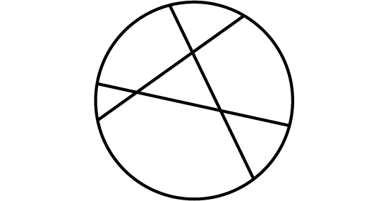

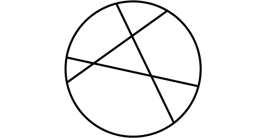

对于这个问题，你的第一反应也许和我的一样：这个问题好傻，谁会这样切蛋糕？这样切出来的蛋糕都是不同形状的，完全没有意义。对于切蛋糕来说，真正重要的是什么？是最多能切多少块，还是切出来的蛋糕大小形状是否平均？

Your first thought about this might be the same as mine: that this is a stupid question, because who would ever cut a cake like that? You end up with pieces of all sorts of different sizes. What matters more in cutting a cake—efficiency, or the sizes of your pieces of cake?

它的意思就是，我们可以把x替换成给定的刀数，代入具体数值后计算出的结果就是能切出来的蛋糕的最多块数。同样，这也是一种抽象，因为你并不是在解决某个具体的问题，而是在讨论一个假设的问题。你并不是真的在解决问题，而是在想如何解决问题。除了写出公式本身外，你也可以把所有可能的答案列成一张表，如下所示：

this is a machine telling us that we can feed in the number of allowed cuts in the place of *x*, and the result will be the number of pieces of cake. This is a form of abstraction, because instead of dealing with actual problems, you’re dealing with *hypothetical* problems. You’re not solving the problem; you’re solving the problem of solving the problem. Instead of writing the formula you could make a table of answers like this:

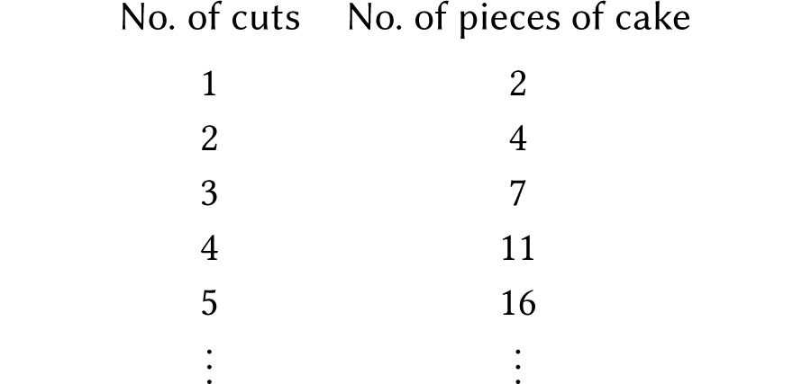

你不可能把这张表真的“写完”，在某个时候，你不得不停下来，因为纸不够用，你的时间也不够用。但公式则不同，它不会“停止”——它是一个可以给出任意给定刀数下你能得到的蛋糕块数的最大值的机器。

You can’t make this table go on *forever*—it will have to stop somewhere, just because you’ll run out of paper, not to mention years of your life. The formula, however, doesn’t stop anywhere—it is a machine for giving you the answer for *any* number of cuts.

也许你不需要准备中等教育普通证书的考试，但也许你的孩子们要准备这个考试，而你需要为他们提供辅导。你辅导他们，但你并不会代替他们参加这个考试。所以，这也是一个元问题——我们要做的不是真的去解决这个问题，而是试图找到让别人能够解决这个问题的方法。教书与此有异曲同工之妙，因为你并不是直接告诉学生们问题的答案，而是试着教会他们自己找到答案——这与你自己直接回答这个问题隔了一层。培训老师又是更上一层的抽象了。以此类推，接下来的一个问题就是，谁来培训这些培训老师的人？

Perhaps you didn’t have to do math investigations, but perhaps you had children doing them, and you were helping them. But you were trying to help them without actually doing the investigation for them. That is the meta-problem—instead of solving a problem, you’re trying to solve the problem of getting someone else to solve the problem. Teaching is a bit like that, because you’re not just telling people answers but trying to get them to find the answers. It’s one level removed from answering the question yourself. Teaching teachers is another level of abstraction. And who teaches the people who teach teachers?

做蛋糕并不需要耗费多少脑力，但发明一种新的蛋糕烹饪方法就不一样了，你需要变得比之前更聪明一些。发现一个新的数字显然已经不是一件多么“有趣”的事，因为我们已经知道给出所有新数字的方法了。如果你找到了治愈癌症的方法，却只是一个病人一个病人地进行治疗，而没有向全世界通报这个治愈癌症的方法，那么这简直可以说是不道德了。

Making a cake isn’t that clever, but inventing a new recipe for making cakes is a bit more clever. Discovering a new number wouldn’t really count as “interesting” because we already know the method for producing all new numbers. If you worked out how to cure cancer, it would be somewhat immoral if you merely went round curing individual people’s cancer instead of teaching the world how to cure cancer.

所有这些关于抽象的例子确实让我们远离了现实一步，但我们由此得到的是一个更广阔的视角。如果你把一支火把放得远一些，这支火把就会照亮更大的区域——但也要注意别放得太远，因为那样的话光就变得太暗了。

All of these examples of abstraction take us arguably one step further from reality, but they have a broader scope as a result. If you shine a flashlight from further away, you will illuminate a larger area. But be careful not to shine it from *too* far away, as the light will then be too dim.

### 抽象的数学Abstract Mathematics

抽象是理解数学的关键。抽象也是数学看起来远离“实际生活”的原因所在。这种与实际生活的疏远正是数学发挥其优势的地方，同时也是它的局限性所在。每一层次的抽象都使得数学更加远离实际生活，也使得解释它与实际生活的关联变得更加困难，因为这种关联有一种多米诺骨牌效应——抽象的数学也许不能直接应用于实际生活，但它可以间接地应用在另一种事物上，而那种事物可以直接应用于实际生活。这样的应用链可以包含好几节，比如：

Abstraction is the key to understanding what mathematics is. Abstraction is also at the heart of why mathematics can seem removed from “real life.” That detachment from reality is where math derives its strength, but also its limitations. Every level of abstraction takes it further from real life, and harder to explain what the relevance to real life is, because the relevance comes from a domino effect—abstract mathematics might not be directly applicable to real life, but rather, applicable to something else which is applicable to real life, or via an even longer chain of applications, for example:

[figure not shown]

抽象是理解为什么数学与普遍意义上的科学有所不同的关键。对以实证为基础的科学来说，证据总是最重要的。首先你需要提出一个“假设”——一个你觉得可能正确的理论，不论这个理论是源自观察、直觉、怀疑、偶然见闻还是其他。然后，你需要通过寻找符合科学标准的证据来严格检验这个假设。这些科学的标准包括：

Abstraction is the key to understanding why mathematics is different from science at large. Evidence-based science proceeds with, obviously, evidence at its heart. You start with a hypothesis—something you believe might be true, whether because of general observation, gut feeling, suspicion, anecdotes, or whatever. Now you need to test the hypothesis rigorously by finding evidence that holds up to scientific standards. Such standards include things like these:

• 样本量要足够大。三四个实证性案例只能被视为“逸事证据”，很可能并不可靠。

• You must have a large enough sample size. Three or four cases is anecdotal and could have been a fluke.

• 证据必须是经过变量控制的。你必须考虑到其他可能影响结果的因素，比如安慰剂效应、社会经济因素、实验参与者的年龄等。

• The evidence must be controlled. You must be sure that you have accounted for other factors that might have affected the evidence, such as the placebo effect, socioeconomic factors, the ages of people involved, and so on.

• 证据必须是客观的、无偏见的。比如，药剂实验就必须被设计为“双盲试验”，也即主试和被试都不知道他们拿到的药剂到底是真正的实验药物还是安慰剂。

• The evidence must be unbiased. For example, drug tests must be double blind—neither the person taking the drug nor the person administering it can know whether it’s a real drug or placebo.

最后，你得到的结果必须符合统计学标准。你可能得到了一大堆非常有说服力的证据，但你的最终结论总是需要附带一个表示该结论确定性的百分比。

In the end, the result is statistical. You come up with a large body of very convincing evidence, but your conclusion always has a percentage certainty attached to it.

数学则与此不同。数学研究的第一步与其他科学没什么不同——提出一个你认为正确的假设。但接下来就不一样了，我们不再使用实证性的方式来严格检验这个假设，而是使用逻辑来严格检验这个假设。此处的“严格”就其定义而言与一般科学意义上的“严格”完全不同。它与样本大小无关，因为数学研究并不涉及任何样本，而只关乎思考、推演的过程。主观感觉也不会影响这个过程，因为我们所做的只是应用逻辑规则而已。

Mathematics is different. The first step is the same—you start with a hypothesis that you think might be true for some reason. But instead of testing it rigorously using evidence, you test it rigorously using *logic*. The meaning of “rigor” is now completely different. It has nothing to do with sample sizes, because you don’t ever use any samples—you only use thought processes. Bias doesn’t come into it either, because all you’re doing is applying logic.

打个比方，假设你想弄清楚要完全覆盖某尺寸的蛋糕表面需要多少糖霜这个问题。你可以直接做个实验——烤一个蛋糕，加上糖霜，然后看看你一共用了多少糖霜。或者，你也可以用逻辑进行推理——做一个关于蛋糕表面积的计算。要计算这个蛋糕的表面积，你需要先对蛋糕的形状进行模拟——比如，你可能需要假设它的表面是一个完全规则的圆形，且表面是完全平滑的。当然，实际生活中并不存在完全规则的圆形和完全平滑的蛋糕。但这个方法的好处在于，你不需要真的去做一个蛋糕才能弄明白具体需要多少糖霜。

For example, to find out how much frosting you need to cover a cake, you could do it experimentally—you could get a cake, frost it, and see how much you used. Or you could do it logically—you could do a calculation involving the surface area of a cake. To do this calculation you have to make an approximation of the shape of a cake. Perhaps you assume it’s perfectly round and perfectly flat on top. Of course, no cake is ever *perfectly* circular and flat. But the advantage of this method is that you don’t have to make any frosting in order to find out how much frosting you need.

使用逻辑推理来代替实验有许多好处。

Using logic instead of experiments has many different sorts of advantages.

##### 实验可能不切实际Experiments Can Be Impractical

假设你现在想知道的是盖一座房子需要多少块砖。显然，为了弄清楚这个问题而专门盖一座房子是不切实际的。与此类似，假如你想弄明白的是改变一条公路的路线会如何影响交通流量呢？

Suppose you want to find out how many bricks you need to build a house. It’s not very practical to build an entire house just to find out how many bricks you’ll need. Or what if you want to work out how changing a road layout will affect traffic flow?

##### 实验可能过于危险Experiments Can Be Dangerous

假如你想知道的是一座桥可以承受的最大运载量呢？显然，你不可能让很多的车辆驶上桥面，然后观察桥会在什么时候崩塌。

What if you want to find out how much traffic a bridge can carry? You can’t just get loads of traffic to drive across it and see when it collapses.

##### 实验可能无法实施Experiments Can Be Impossible

假如你想知道的是为什么太阳每天都会升起来，或者为什么行星的运行轨迹是这样而不是那样的呢？你显然不可能改变外太空的状况，然后看看行星会不会改变运行轨迹。

What if you’re trying to work out why the sun rises every day, or why the planets behave the way they do? You can’t just change the conditions of outer space and then see how the planets behave differently.

##### 实验可能会引发灾难Experiments Can Be Undesirable

假如你想知道的是某种传染病是如何传播的呢？显然，你不可能在人群中散播这种疾病的传染病菌，然后看看它是如何传播的，因为这正是你想避免的事情。

Suppose you’re trying to work out how an infectious disease can spread across the country. You can’t just unleash the disease and see how it spreads, because that’s exactly the thing you’re trying to avoid.

##### 实验可能是不道德的Experiments Can Be Immoral

在我写作本书的时候，我听说有人提出了扑杀獾可以减少牛群肺结核感染率的主张。但是，我们该怎样检验这个假设呢？通过杀死很多獾来看看结果如何真的合乎道德吗？

At the time of writing, there is a suggestion that culling the badger population will reduce instances of tuberculosis in cows. How can this be tested? Is it morally right to kill a whole lot of badgers to see what happens?

在以上这些情况中，逻辑推理显然要更胜于实验论证。前者最重要的优势在于，借助逻辑推理，你所得出的结论不仅仅是“几乎肯定是正确的”，更是完全不可辩驳的。

In all these cases, there is an important advantage to working theoretically rather than experimentally, an advantage to using logic rather than evidence. The final crucial advantage is that with logic, the conclusion is not just “almost certainly true”: it is irrefutable.

### 逻辑是如何运作的？How Does Logic Work?

逻辑性论据包含一系列的主张，其中的每一个判断都是完全依据逻辑由上一个判断推导出来的。这很好理解，但问题在于，第一个判断从何而来？例如，你可以假设你的蛋糕表面是完全规则的圆形。你可以假设一个携带传染病菌的人遇到另一个人后将这种疾病传染给对方的概率是50%。这些基础的假设构成了抽象过程的一部分。它们通常会涉及对实际生活中的事物的理想化，由此你就可以运用逻辑对它们进行推理。这种做法的弊端在于，经过理想化的事物与实际生活中的事物不完全相同；而它的优势在于，在完成了理想化处理之后，你就可以运用逻辑来分析它们并得出结论了。你得到的最终结果的不准确之处就源于你最初对实际问题进行抽象化处理的过程中所丢掉的信息。这与统计结果截然不同，因为后者的不准确之处在于，虽然有证据支持你的假设，但你的假设仍然有很小的概率是错的。

A logical argument is a series of statements, each of which follows from the previous one using only logic. That’s all very well, but where does it start? You always have to start with a basic set of assumptions. For example, you might assume your cake is perfectly circular. You might assume that an infectious disease has a 50 percent chance of being passed from one person to another if they meet. These basic assumptions are part of the process of abstraction. They usually involve turning your real-life objects into something theoretical, so that you can reason with them using logic. The downside is that your theoretical situation won’t be *exactly* the same as your real one. But the upside is that you will now be able to apply logical process to work things out about them. The inaccuracy of your final answer will now come from the information you threw away when you performed the initial abstraction. This is very different from statistical results, where the inaccuracy of the final answer comes from a small possibility that your hypothesis was wrong despite the evidence.

采用数学的方法（与之相对的是通常人们所说的“科学的方法”）要求你必须清晰地陈述你的假设是什么。人们可以不同意你的假设，但是他们不能不同意你的结论，也就是说：

The *mathematical method* (as opposed to the more talked-about scientific method) involves making very clear what your assumptions are. People can then disagree with your assumptions, but they aren’t entitled to disagree with your overall conclusion, which is:

如果我们做了这样的假设，那么由此假设推导出的这个结论就是正确的。

*If* we make these assumptions, *then* this conclusion is true.

例如，如果一只鸡够10个人吃，那么两只鸡就够20个人吃。你可以不同意一只鸡够10个人吃这一假设（也许不够10个人吃，除非是某种转基因巨型鸡），但你不能不同意这个结论：

For example: if one chicken can feed ten people, then two chickens can feed twenty people. You can argue about how many people one chicken can really feed (probably not ten people unless it’s a scary genetically modified giant chicken), but you can’t argue with the fact that:

如果一只鸡够10个人吃，那么两只鸡就够20个人吃。

*If* one chicken feeds ten people, *then* two chickens feed twenty.

但这个结论还是存在一个可能的漏洞：所有的鸡都一样大吗？我们也许可以加上“所有的鸡大小都差不多”这条假设以确保这个问题可以用数学解答。

But there’s still a possible flaw here: are all the chickens the same size? We probably need to add an assumption saying “All chickens are about the same size” to ensure that the situation behaves mathematically.

这是一个不切实际的假设吗？如果你要给一个40人的聚会订烤鸡，那么你很有可能需要做类似的运算，即便每只鸡的大小并不是完全一样的。当然，你也可以用实验的方法来解决这个问题：也许你可以依赖餐饮服务商的经验，理论上他们拥有足够多的聚会餐食供应经验，知道你应该订多少只鸡。

Is this an unrealistic assumption? If you’re going to order whole roast chickens for a party with forty people, you’re probably going to do a calculation somewhat like this, even though chickens aren’t all *exactly* the same size. But on the other hand, you might proceed experimentally instead: you might rely on the experience of the caterer, who has probably held enough parties to have experimental evidence of how many chickens to get for forty people.

抽象之所以让人觉得难以理解，是因为它带我们离开了具体事物的世界，而进入只存在于头脑中的“概念”的世界。但有一些抽象概念我们已经十分熟悉了，因而我们不再能意识到它是一种抽象。打个比方，如果我们开始思考一般的鸡有多大这个问题，我们事实上就已经在进行抽象思考了：一只“一般的鸡”并不是一只具体的鸡，而是一个关于鸡的概念。还有我之前提到的，数字也是一种抽象。数字1、2、3、4……只是一些概念。也正是因为它们是概念，我们才得以使用纯粹的逻辑推理来处理它们。

Abstraction can be difficult because it takes us out of the realm of physical objects and into the realm of “ideas” that we manipulate only in our head. But there are some abstract ideas we’re so used to that we don’t even notice how abstract they are any more. If we think about the size of an average chicken, that’s an abstraction right there: an “average chicken” isn’t a real chicken we’re considering, it’s just an idea of a chicken. As I mentioned before, numbers are abstract. The numbers 1, 2, 3, 4, and so on are only *ideas*. Because they are ideas, we can manipulate them just using logic.

抽象的美妙之处在于，在你对某个抽象概念已经非常熟悉了以后，它似乎就变成了一个具体的事物，而不再是一个想象出来的概念。你也许已经很习惯“2”这个概念，这意味着你已经适应了这种程度的抽象。而对于“-2”这个概念，你可能就没有那么习惯了。那么2的平方根呢？这是一个自己乘以自己等于2的数字。但它到底是什么呢？你也许会说它是1.414…，但这是一个无限不循环小数——你没办法把整个数字写出来，如此一来你该如何知道它到底是什么呢？那么-1的平方根呢？我们稍后会进一步探讨这些问题，并说明为什么对于严格的数学来说，2的平方根比-2的平方根更复杂，甚至比-1的平方根更复杂，虽然直觉上我们会认为-1的平方根更难理解，因为“现实生活”中并不存在与此对应的实际事物。

The wonderful thing about abstraction is that when you get very used to an abstract idea, it starts to *feel* like an actual object instead of just being a made-up idea. You’re probably quite comfortable with “2” as a concept. That means you’re comfortable with that level of abstraction. Perhaps you’re less comfortable with exactly what “−2” is. What about the square root of 2? It’s a number such that when you multiply it by itself, the answer is 2. But what actually is it? You might think it’s 1.414 . . . , but that is a decimal that goes on forever without recurring—you can’t write the whole thing down, so how do you know what it is? What about the square root of −1? We’ll investigate these questions in more depth later, and look at why rigorous mathematics has much more trouble with the square root of 2 than with −2 or even the square root of −1, even though intuitively the square root of −1 is much harder to think about because nothing like it ever appears in “real life.”

抽象这一过程多少有些类似于运用你的想象力。数学的抽象带领我们进入一个想象的世界，在这里，任何事情都有可能发生，只要它的存在不是自相矛盾的。你能想象透明的乐高积木吗？这并不是很难。那么软软的像橡皮泥一样的乐高积木呢？这就有些奇怪了。那么被碰到就会自动变颜色的乐高积木呢？或者四维的乐高积木？隐形的乐高积木？早上会给你煮咖啡的乐高积木？当然，你能想象出来一样事物，并不意味着它就能存在于实际生活中——尤其是如果你的想象力很丰富的话。而数学世界的美妙就在于，一旦你想象出一个数学概念，它就真正在这个世界中存在了。你的想象力越丰富，你就越有机会探索更多的数学领域。

Part of the process of abstraction is like using your imagination. Mathematical abstraction takes us into an imaginary world where anything is possible as long as it’s not contradictory. Can you imagine transparent Lego blocks? That’s not so difficult, but what about squashy Lego blocks? That’s a bit more strange. What about Lego blocks that spontaneously change color when you touch them? Four-dimensional Lego blocks? Invisible Lego blocks? Lego blocks that can make coffee for you in the morning? Obviously in the real world, just because you can imagine something doesn’t mean it actually exists—particularly if you have a very vivid imagination. The amazing thing about the world of math is that mathematical things exist as soon as you imagine them. The more vivid your imagination, the more math you have access to.

另一个我们很熟悉的抽象概念是形状。正方形是什么？它是一个包含4条相等的边和4个相等的角的形状。但现实生活中存在完美的正方形吗？不存在。仔细考量的话，现实生活中的正方形都不是绝对完美的正方形。圆形也是如此。直线呢？真的存在完美的直线吗？我想答案是否定的。不过，虽然现实生活中的直线不过是趋近于完美直线这个概念的近似物，但我们显然已经非常习惯使用这个概念了。

Another abstract concept that we’re quite used to is shapes. What is a square? It’s a shape with four equal sides and four equal angles. But are there actually any *perfect* squares in the world? No, any physical shape in the real world is not going to be an absolutely microscopically pedantically perfect square. Likewise circles. What about straight lines? Are there really any perfectly straight lines? Not really. And yet we’re comfortable with the idea of a straight line, although the things in the real world are only approximations to this ideal.

### 运用抽象来计算Abstraction at Work

现在我来讲讲如何用抽象的办法解决我们之前提出的两个问题，这样你就可以看出抽象化具体是怎么运作的了。

Here I will give the abstract approach to the two example questions I posed earlier on, so you can see what it looks like.

我爸爸的年龄现在是我的3倍，而10年以后他的年龄将会是我的2倍。那么我现在几岁呢？

*My father is three times as old as I am now but in ten years’ time he will be twice as old as me. How old am I?*

到目前为止还很简单。但“10年后他的年龄将会是我的年龄的2倍”就有些复杂了。这一步的关键就在于，10年之后，我的年龄将会变成x+10，他的年龄将会变成y+10；我们还知道，那时候他的年龄将会是我的2倍，也就是说：

So far so good. “In ten years’ time he will be twice as old as me” is a bit trickier. The key is that in ten years’ time my age will be *x* + 10 and his age will be *y* + 10, and we know that his age will be twice mine at that point, so this turns into:

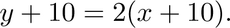

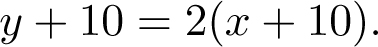

我们可以将第一个等式代入第二个等式，即用3x替代上面这个等式中的y，如此，我们就得到：

We can now substitute 3*x* into the second equation where *y* is, so we get:

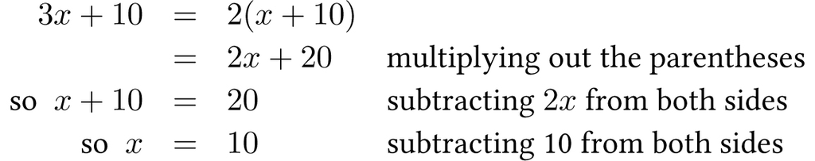

所以我们得出结论：我现在的年龄是10岁（我爸爸的年龄为30岁）。

So we can conclude that I am 10 years old.

请注意，在上述计算中，我们采用了如下几个步骤：

Note that we went through the following steps.

1. 我们从一个用文字描述的“实际生活”问题入手。

1. We started with a “real-life” situation expressed in words.

2. 我们运用抽象的方式将这个问题转变为逻辑概念。

2. We performed an *abstraction* to turn it into logical concepts.

3. 我们借助逻辑规则来处理这些抽象的概念。

3. We manipulated the abstract concepts using logic.

4. 我们取消抽象，将问题的答案放回实际生活场景之中。

4. We undid the abstraction to get back to the real-life situation.

我们还可以进一步抽象。刚才我们所进行的工作帮助我们解决了上述那道应用题，但如果进一步抽象，我们就可以解决所有类似的问题。

There’s a further level of abstraction we can do here. The step we did helped us solve the problem stated in words above, but if we do another step, we can solve *all similar problems*.

对于刚才的题目，我们是从两个具体的方程入手的：

In that problem we started with two specific equations

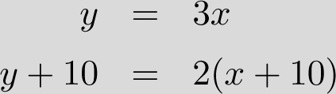

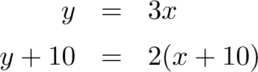

现在，我们可以用字母来替代那些具体的数字，这样我们就可以解决参数为任意数字的这两个方程了：

but we could replace all those numbers with letters so that we can solve any pairs of equations involving any numbers:

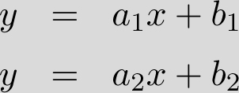

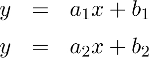

如果我们把包含x的项都放到同一边，我们就得到了：

And now if we put all the *x* terms on one side we get

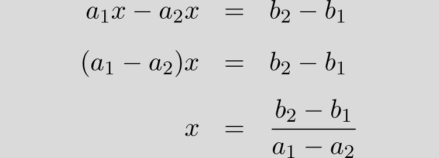

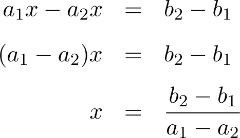

除a<sub>1</sub>=a<sub>2</sub>这种特殊情况外，我们在最后一步得出的解都是有效的；而如果是a<sub>1</sub>=a<sub>2</sub>，则我们必须使b<sub>1</sub>=b<sub>2</sub>，也就是说，与y相关的两个等式是一样的，如此我们就没有足够的信息来确定x和y的具体数值了，这意味着，这个问题有无穷多的解。

This last step is valid unless *a*<sub>1</sub> = *a*<sub>2</sub>; in this case we are forced to have *b*<sub>1</sub> = *b*<sub>2</sub> as well, which means the two equations are the same, and we don’t have enough information to pin down what *x* and *y* have to be—there will be infinitely many solutions.

现在我们来看另一个例子。

Let’s try the other example.

我已经知道覆盖一个6英寸蛋糕的表面和侧面需要用到多少糖霜了。那么，覆盖一个8英寸蛋糕的表面和侧面需要用到多少糖霜呢？

*I have a recipe for frosting the top and sides of a 6-inch cake. How much frosting do I need for the top and sides of an 8-inch cake?*

我们假设两个蛋糕的表面都是圆形，而且都有2英寸高。我们需要算出6英寸和8英寸蛋糕的糖霜覆盖面积，看看后者比前者大多少。因为两个蛋糕的表面都是圆形的，所以直接计算半径为r的蛋糕表面的面积相对省力，只需要代入r=3或 r=4（半径为直径的一半）即可。以下为具体步骤：

We *assume* that both cakes are round and 2 inches deep. We need to find the area of frosting used in the 6-inch cake, and the area used in the 8-inch cake, and see how much bigger the latter is. Because both cakes are round, we can save some effort by calculating the area of frosting on a cake of radius *r*, and then we can use *r* = 3 or *r* = 4 afterwards (the radius being half the diameter).

• 蛋糕的表面是一个圆形，所以这个圆形的面积为πr2。

• The top of the cake is a circle, so the area is *πr*2.

• 蛋糕侧面的面积是它的高度乘以圆形表面的周长。圆形周长为2πr，所以蛋糕侧面的表面积为2×2πr=4πr。

• The side of the cake has an area that is the height times the circumference. The circumference is 2*πr*, so the area is 2 × 2*πr* = 4*πr*.

• 所以，覆盖一个表面半径为r的蛋糕所需的糖霜为πr2+4πr。

• Thus the total frosting for radius *r* is *πr*<sup>2</sup> + 4*πr*.

现在，我们可以用这个方法来算出覆盖两个不同尺寸的蛋糕分别所需的糖霜：

We can now use this formula to work out the area covered by frosting in each of the two cakes.

• 对于6英寸蛋糕来说，其半径为3，所以我们需要糖霜覆盖的总面积就是：

• For the 6-inch cake the radius is 3, so the total area covered by frosting is

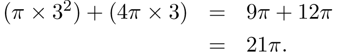

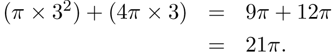

• 对于8英寸蛋糕来说，其半径为4，所以我们需要糖霜覆盖的总面积就是：

• For the 8-inch cake the radius is 4, so the total area covered by frosting is

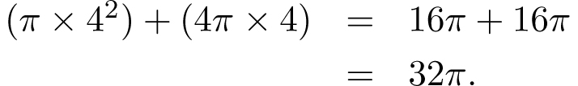

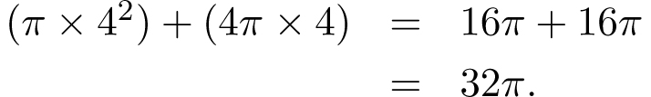

因为这只是一个关于覆盖蛋糕表面需要用到多少糖霜的问题，而不是一个有关用药剂量之类需要精确计算数值的问题，所以我们在这里取一个近似值即可：32/21大约等于1.5，也就是说，你需要依照6英寸蛋糕配方中配料的1.5倍来准备，才能做好8英寸蛋糕的糖霜。

在这个问题中，值得注意的是，我们做了一个假设，即蛋糕有2英寸高，所以最终的答案可能不够准确，但不准确的原因只在于这个假设。所以我们最终的、无法辩驳的结论是：

The important thing to notice here is that we made an *assumption* that the cake is 2 inches high. So the final answer might be inaccurate, but only because of this assumption. So our final, irrefutable conclusion is:

如果所有蛋糕都是2英寸高，

*If* all the cakes are 2 inches high,

那么我们就需要按原配方中配料的1.5倍准备原材料。

*then* we need to multiply the original recipe by 1.5.

这个关于蛋糕的例子比那个计算儿子和爸爸的年龄的例子更实用一些。关于年龄的那个问题只是一个简单的脑筋急转弯，而关于糖霜的这个问题则是一个抽象思维在现实生活中帮助我们解决问题的实例。当然，我们也可以通过实验的方法得出答案，比如做出一大堆糖霜来看看大一些的蛋糕会用掉多少，但那样做很可能会造成浪费。抽象的方法会耗费更多的脑力，但它不会浪费那么多的糖霜。  
1英寸≈ 2.54厘米。——编者注

This cake example is somewhat more useful than the example with my father’s age. Where the question of age was just a silly brainteaser, the question about frosting was a genuine situation where the abstract thought processes helped us. We could have worked out the answer experimentally, by making a whole load of frosting and seeing how much we needed for the bigger cake, but that would have been a waste of frosting. The abstract approach used more brainpower but wasted less frosting.

† 路标图像的版权归英国王室所有，依照《开放政府许可协议》转载。

† Road sign images are Crown Copyright and reproduced under the Open Government Licence.

## 3 原理Chapter 3 Principles

### 会议巧克力蛋糕Conference Chocolate Cake

#### 配料Ingredients

5 盎司软化的黄油

5 oz. butter, softened

5 盎司糖

5 oz. sugar

2 个大鸡蛋

2 large eggs

5 盎司自发面粉

5 oz. self-rising flour

可可粉，按口味添加

Cocoa powder to taste

约 7 小块巧克力

About 7 squares of chocolate

#### 做法Method

1. 将黄油与糖搅打成蓬松的奶油状。

1. Cream the butter and the sugar.

2. 打入鸡蛋，再轻轻拌入面粉。

2. Beat in the eggs, then fold in the flour.

3. 打入可可粉，直到混合物呈深棕色。

3. Beat in cocoa powder until the mixture looks dark brown.

4. 将面糊装入 14 个小硅胶松饼模，装至半满；每个放入半小块巧克力，再盖上一些面糊。

4. Half-fill 14 small silicone muffin cups with the mixture, then put half a square of chocolate in, and cover with more of the mixture.

5. 以 350°F 烘烤约 10 分钟，出炉后立即食用。

5. Bake at 350°F for about 10 minutes. Eat immediately.

我管这个配方叫作“会议布丁”，是因为我第一次做它是在一次会议晚宴之后，一大群数学家高高兴兴地涌入我的公寓，请我做一些布丁吃。我不得不在我家的厨房里拿现有的材料进行即兴创作。幸运的是，我总是在厨房里备有很多的巧克力。如此，我就可以参照烤蛋糕的基本原理来制作布丁了。同等分量的鸡蛋、面粉、黄油和糖就是一个不错的起点——我知道有很多其他的蛋糕配方非常复杂，但我们没必要把它们用在这里，不是吗？大多数人都喜爱巧克力，而且放一些巧克力在布丁中间会让布丁内馅儿变得柔软黏稠，而这种温热、黏稠的内馅儿带来的味觉快感会淡化人们对布丁其他部分的注意。

I call this “conference cake” because I first made it after a conference dinner when a whole group of mathematicians piled into my apartment feeling merry and asked me to make dessert. It was a case of improvising something with whatever was in the kitchen. Fortunately, my kitchen always contains a large quantity of chocolate. Then I could follow some of the basic principles of cake making. Equal quantities of egg, flour, butter, and sugar is a good basic starting point—other cake recipes can get very complicated, but what for? Chocolate usually makes people happy, and putting some in the middle of each cake means that the middle is gooey, and the excitement of the oozing middle will distract people from whatever else happens with the desserts.

重点在于，如果你理解了一个过程背后的原理，而不是只记住整个过程，你就能更有效地控制这个过程，而一旦出现问题，你也可以更有效地进行解决，并且可以更好地调整整个过程的部分环节，以使这个“配方”适用于不同的目的。除此之外，在面临极端情况（如缺少配料、器具损坏或喝醉酒身体不适……）的时候，你也能应对得更加游刃有余。

The point is that if you understand the *principle* behind a process rather than just memorizing the process, you will be much more in control of the situation, better able to fix it when it goes wrong, in a better position to modify the process for different purposes, and better able to cope in extreme situations such as missing ingredients, broken equipment, drunkenness. . .

### 在醉酒的时候烘焙Drunk Baking

#### 如何应对极端情况Coping in Extreme Situations

在醉酒的时候开车很危险，这种做法在任何时候都是应该避免的。不过，在醉酒的时候烘焙则很有趣（如果你知道自己在做什么的话）。除了严格遵照食谱进行操作，理解烤蛋糕背后的原理还有别的理由。比如，也许你的朋友对小麦过敏，那么你就必须烤制不含小麦的蛋糕。（就我的个人经验而言，小麦粉在烤布朗尼蛋糕时的最佳替代品是土豆粉，在烤奶酥时的最佳替代品是燕麦粉，在烤千层饼时的最佳替代品则是大米粉。）

Drunk driving is dangerous and to be avoided at all times. However, drunk baking is quite fun if you understand what you’re doing, so when friends end up at my place after a night out, I’m always happy to make an experimental dessert. There are other reasons to understand the basic principles of cakes instead of just faithfully following recipes. You might have friends with gluten intolerance, so you need to make cakes without wheat flour. (I’ve found that the best substitute flour for brownies is potato flour; for fruit crisps it’s oat flour, and for pastry it’s rice flour.)

或者，也许你想做低脂蛋糕，那么你就需要理解脂肪在蛋糕烘焙中扮演的角色，即制造气泡，如此一来，你就可以使用能够发挥相同作用的食物来替代油脂，比如一种很特别的配料——苹果泥。

Perhaps you want to make cakes with less fat. So you need to understand the role the fat is playing in the cake—creating air bubbles—so that you can replace it with something that will play the same role, for example, curiously, apple sauce.

理解方法背后的原理还能帮助你在不搞砸整个过程的前提下走捷径，而且，如果你像我一样懒的话，你就会一直用这种办法找捷径，或者简化步骤。比如，当你处于醉酒状态时，分离蛋清和蛋黄会变得困难很多。而涉及巧克力的食谱通常都会包含这句话：

Understanding the principles behind methods also helps you take shortcuts without ruining everything, and if you’re lazy like me, you’ll be looking for shortcuts all the time. Or simplifications because, for example, separating eggs turns out to be much harder when you’re drunk. Recipes involving chocolate often say something like

把巧克力掰成小块，放在一个可以用于加热的碗里，把碗放在平底锅中，在锅里倒入水，慢慢煮开，确保碗底不会碰到平底锅的底。搅拌巧克力块直至融化。

*Break the chocolate into small pieces and place in a heatproof bowl. Set the bowl over a pan of simmering water, ensuring that the base of the bowl does not touch the base of the pan. Stir until melted.*

但我们知道，这句话实质上想说的就是“将巧克力融化”。而我因为实在好奇为什么碗底不能碰到平底锅的底而尝试了这种“错误”的做法，却发现结果好像并没有什么不同。实际上，我还经常借助微波炉来融化巧克力，或者，更好的办法是，将盛放巧克力的器皿直接放在电磁炉上，调小火加热。烹饪书很少向你解释为什么你要这样做某个步骤，这让我很沮丧。但是，理解就是力量。如果你帮助某人更好地理解了某样东西，你就赋予了他更多的力量。也许那些烹饪书的作者是故意这么做的，他们不想让我们理解太多，否则我们可能就不需要他们来发明食谱了。

But what they really mean is “Melt the chocolate.” I eventually became curious about this business of not letting the bowl touch the bottom of the pan and so tried it—and it didn’t seem to make any difference. I also often melt chocolate in the microwave or, best of all, the oven at a low temperature. Recipe books rarely explain why they’re telling you to do something, which I find frustrating. But then, understanding is power, and if you help someone understand something, you’re giving them power. Perhaps those writers don’t want us to understand too much, otherwise we wouldn’t need them to invent recipes for us.

在数学中，一个类似的例子就是乘法表。将乘法表背下来的确很有用，因为这样一来你就不需要在每一次计算时都扳着手指头数数了。但理解乘法表中的运算结果是怎样得出来的也很重要，这样一来，万一你忘记了其中的某些数字，你仍然可以手动计算出结果。

For a mathematical example, it’s useful to memorize your times tables, rather than having to count on your fingers each time. But it’s also useful to understand how to work out the times tables in case you forget and need to work them out from scratch.

顺便一说，烹饪书总是会告诉你要用塔塔粉做蛋白糖霜脆饼，但我从没用过这种食材，而我的蛋白糖霜脆饼依然十分完美，美味无比。

By the way, recipes always say to use cream of tartar in meringues, but I never have, and my meringues seem perfectly fine. Delicious, even.

### 焊接Welding

#### 为理解汽车工作原理而进行的尝试My Attempt at Understanding How Cars Work

我16岁的时候曾因为焊接上了电视。当时，学校布置了一项关于汽车的作业，我们小组需要在两位物理老师的指导下把一辆旧名爵汽车分解，然后组装上新的部件。出于某种原因，我比其他人更擅长焊接，并且我觉得这项工作很让人激动——那些噪声、四散的火花、由高温作业带来的温度上升、它所包含的潜在的危险性，以及用加热的方式将金属连接起来的“魔力”，都让我深深着迷。对比之下，我并不很擅长理解整辆车的运作原理。我所做的只是焊接老师叫我焊接的那些零件。

When I was sixteen I was on television welding. I was working on a car project in high school, where we were taking an old MG apart under the supervision of two of our physics teachers and rebuilding it with new parts. For some reason I was the best at welding, and I also found it quite exciting—the noise, the sparks, the heat, the danger, and the “magic” of joining metal together using heat. By contrast, I wasn’t very good at understanding how the whole car worked. I just welded whatever I was told to weld.

我猜当地电视台也许是因为觉得一帮女生组装一辆车这件事很奇怪（希望现在这件事不会再被认为奇怪了），所以就决定把我们当作拍摄题材。于是理所当然，我焊接零件的场面也被拍了进去。  
采访者问我们是不是想要以此来吸引我们未来的男友，但对我个人而言，我只是因为想理解汽车的工作原理才做这件事的。我仍然认为，理解一件你一直在使用的工具其背后的工作原理是个很好的主意，因为这样一来，在发生故障的时候，你就掌握了更多的主动权，并且你也更有可能让这件工具最大限度地发挥效用。问题在于，随着科技的进步，事物的原理越来越多地被埋藏在电子元件和程序代码中，因而也就更难以被拆解开来，一一理解。在我学会开车之后的一段时间里，我碰到的大多数问题都是电子方面的，而非机械方面的。  
不幸的是，当时我试图理解汽车工作原理的计划失败了。我学会了如何焊接，但没能进一步理解汽车的工作原理，所以当我的车遇到问题的时候，除了请求专业人士的帮助，我依然没有其他选择。而对于数学，如果我遇到了问题，我还是有可能自己搞定的——至少，我可以检查一下我的推理，看看其中是否存在逻辑漏洞。

I suppose the local TV station was amused by the idea of a bunch of girls building a car (I hope that doesn’t seem so funny these days), so they turned up to film us one day, and I was duly filmed welding something. The interviewers asked us if we were doing it to impress future boyfriends, but I was doing it because I wanted to understand the principle of how a car worked. Unfortunately, I failed. I know how to weld, but I ended up none the wiser about how a car works, so now if my car breaks down I still have little choice but to take it to an expert. I still think it’s a good idea to know the principles of something that you’re using all the time, so that you’re less at its mercy when it goes wrong and so that you have a better chance of getting the best out of it. The trouble is that with the advance of technology, the workings of things have become more and more deeply embedded in electronics and code, so it’s much harder to just take something apart and stare at it.

如果在学数学的过程中，孩子们总是得出错误的解答，而找不到错出在哪里，那么数学这门课就很可能会让他们失去信心。这就是为什么在数学教学中，很重要的一件事是理解学生的思维方式，并且指出他们思考过程中的逻辑错误出在哪里，而不是只看最终答案是错是对。

At least if my math “breaks down” I have a chance of fixing it myself—that is, I can check my reasoning and see where my logic was flawed. Math can be demoralizing for children if they keep getting the wrong answer but they don’t see what went wrong. That’s why it’s so important when teaching math to understand the student’s way of thinking, and point out what was wrong with their logic, not just what was wrong with their final answer.

### 火星Mars

#### 当我们在某颗地外星球上寻找生命的时候，我们首先在找的是什么？What Do We Look for First When Looking for Life There?

当我们在另一颗行星上寻找生命存在的证据时，我们首先寻找的是水存在的迹象。这是因为我们已经得出结论，或者说已经认定，水对生命体是至关重要的。

When we look for the possibility of life on another planet, we start by looking for signs of water. This is because we’ve worked out, or decided, that water is pretty much crucial for making life viable.

欧洲的探索者在遥远的殖民地做了许多错误的决定（包括殖民这件事本身），其中之一就是试图在完全不同的气候条件下种植从欧洲带过去的农作物。他们完全不理解是什么使得农作物生长，因而也就不知道为什么这些农作物在当地气候炎热、土壤贫瘠的地理条件下无法健康生长。也有可能，他们根本没有预料到这些遥远的殖民地的气候会与欧洲截然不同。不管出于什么原因，这些农作物最终都没能长成。

When European explorers colonized faraway lands they did many things wrong (not least, perhaps, the colonization in the first place). One thing they did wrong was try to bring crops with them from Europe to grow in lands with rather different climates. They had not in any way understood what was necessary to make those crops grow and that the crops would therefore fail in those hotter, harsher lands. Or maybe they hadn’t understood just how different the faraway climate was going to be. In any case, the crops failed.

学习事物背后的运作原理的目的之一就是理解到底是什么使得它能够正常运作，如此一来你才可能知道，当你前往一个遥远的地方，发现其地理条件与之前截然不同时，它是否还能正常运作。对于遥远的数学之地，这个道理同样适用。

One purpose of studying the principles behind things is to understand what is really making a situation work, so that you know whether it will still work when you go to a faraway land. That’s a faraway *mathematical* land.

比如，“自然数”是我们最为熟悉的数学领域之一。这个概念指的是我们数数时所使用的数字：1、2、3、4……它们被称为“自然数”是有原因的——它们的存在对人们来说很自然。但问题就是，我们对它们实在太熟悉了，因而也就注意不到我们使用它们的地方。就像只有当你的手臂受伤时，你才会意识到平时习以为常的、使用双手做的事情现在竟然变得如此困难。我们也许并不会注意到什么时候我们需要同时使用两只手，什么时候只用一只手就够了。刷牙似乎是单手就可以完成的活动，但你要怎么用单手把牙膏挤到牙刷上呢？吃薯片似乎只用一只手就够了，但你要怎么用单手把包装袋打开呢？

For example, one of the mathematical lands we feel most at home with is the *natural numbers*. These are the numbers we use for counting: 1, 2, 3, 4, and so on, and they’re called “natural numbers” for a reason—they feel very natural. The trouble is, they’re so natural we don’t even *notice* the things that we’re using about them. It’s like when you break your arm, and you suddenly notice all sorts of things that are difficult, things that you entirely take for granted when you have the use of both hands. We might not really notice when we particularly need to use both hands at once, or when one solo hand will do. Brushing your teeth seems like a one-handed activity, but how do you get the toothpaste on the toothbrush? Eating chips seems one-handed, but how do you open the bag?

自然数也是这样的。我们理所当然地认为我们可以进行加法和乘法计算，无论数字相加或相乘的顺序为何。我们认为8+4和4+8是一样的，并且我们经常使用这个规律来简化计算——把小数字加到大数字上面比把大数字加到小数字上面更简单。对于那些还在扳着手指数数的孩子而言，这个规律更是有用。比如计算2+26，如果是把26加到2上面，孩子们需要数上很久，但如果是从26开始数2个数，计算就会快上很多——而对于老师来说，难处就在于说服孩子们把两个数字换位置以后进行相加，两者所得到的答案是一样的。

Likewise with the natural numbers. We take for granted that we can add and multiply, and that it doesn’t matter what order we do it in. 8 + 4 is the same as 4 + 8, and we often use this when we’re adding up—it’s much easier to add a small number onto a big number, rather than adding a big number onto a small number. This makes an especially significant difference to small children who are still adding by counting on their fingers. 2 + 26 will take a very long time if they start with 2 and count on 26, but if they start with 26 and count on 2 it will be quite quick—the difficulty for the teacher is in convincing them that they will still get the same answer.

同样，6×4和4×6的结果是一样的。这对我们来说是一件好事，因为这意味着我们只要背下来乘法口诀表的一半就够了。对我个人而言，在计算4×6的时候，我只能把这个计算理解为“6个4”，而不是“4个6”。同样，在计算8×6的时候，我只能把它想成“6个8”，而对8×7来说，我则必须把它想成“7个8”。下面这张表展示了乘法口诀表中我相对熟悉和不太熟悉的部分——也许你也有类似但不同的偏好？你更喜欢“8个6”，还是“6个8”，还是二者皆可？

Likewise, 6 × 4 is the same as 4 × 6, which is a good thing, because it means we only have to remember half our times tables. Personally I can only do 4 × 6 by thinking of it as “six fours” and not “four sixes.” I have to think of 8 × 6 as “six eights.” But 8 × 7 I have to think of as “seven eights.” Here’s a grid of which times tables I do and don’t know—perhaps you have something similar but different? Do you know “eight sixes” or “six eights” or both?

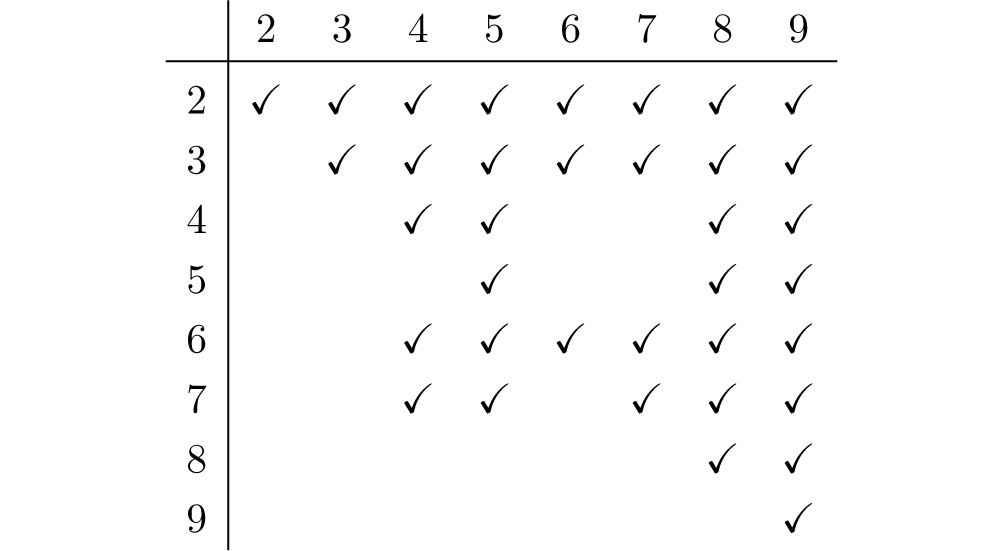

对于这张表，我是先从上往下背，然后再从左往右背的，所以我更熟悉“6个5”，但没那么熟悉“5个6”。我并不知道我的大脑为什么会以这样的方式处理乘法口诀表，不过幸运的是，把乘号前后的两个数字交换位置后得到的答案是一样的，这样一来即便我没能背下所有的口诀，我也能根据我知道的那些推导出其他的答案。

In this grid I’m reading down first, then across. So I don’t know “five sixes,” but I do know “six fives.” I have no idea how my brain ended up dealing with times tables this way. Fortunately, turning the multiplication around gives the same answer, so I can *deduce* all my times tables, even if I don’t actually *know* them all.

但是，如果我们进入了一个这些原理不再适用的数学领域呢？在这种情况下，我们不得不开始努力思考这些原理都引起了哪些连锁反应。所有的事情都会开始出错。我们还能解方程吗？我们还能画图表吗？我们用于解决所有问题的常规办法还能适用吗？在本书的后面，我会对这些问题给出解答。

But what if we went to a different mathematical world in which these helpful facts weren’t true? We would need to think very hard about what the knock-on effect would be. All sorts of things would start going wrong. Would we be able to solve equations any more? Would we be able to draw graphs? Would our standard techniques for *anything* work any more? We’ll find out later in the book.

一个与自然数有关的有趣的原则是关于质数的。要知道，质数就是只能被1和它自己整除的数（而且1不是质数）。所以最开始的几个质数是：

A more interesting principle of the natural numbers is to do with prime numbers. Remember, a prime number is one that is only divisible by 1 and itself (and 1 doesn’t count as prime). So the first few prime numbers are

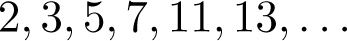

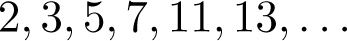

现在，对于任何一个数，我都可以把它写成一个质数运算的结果。比如，6=2×3，除此之外没有其他质数相乘可以得到6，除了把2和3交换位置，而这也算不上不同；再比如，24=2×2×2×3，除此以外没有别的质数相乘可以得到24这个结果。这是自然数的一个很重要的特性，但它并不适用于数学的所有领域。

Now if I think of any number at all, there will be a unique way of writing it as a product of prime numbers. For example, 6 = 2 × 3, and there’s *no other way* of multiplying prime numbers together to get 6, except by changing the order and doing 3 × 2, which doesn’t count as different. 24 = 2 × 2 × 2 × 3, and there’s *no other way* of multiplying prime numbers together to get 24. And so on. This is a very important property of the natural numbers, but it *doesn’t* hold on all mathematical planets.

这就给数学的探索者制造了一些麻烦，就像欧洲殖民者在与家乡截然不同的气候条件下试图种植来自家乡的农作物一样。比如，几次证明费马大定理的尝试都失败了，因为当时的研究者认为他们是在一个质因数分解定理成立的数学领域里分析这个问题的，但事实并非如此。他们假设火星有水存在，并据此设计了一个非常“聪明”的火星探索计划。

This has created problems for mathematical explorers just as unfamiliar climates did for those trying to plant crops in faraway lands. For example, several attempts at proving Fermat’s Last Theorem turned out to be wrong because people thought they were working on a planet where this prime factorization property was true, when in fact it wasn’t. They had devised a brilliant mission to Mars assuming there was water there.

费马大定理是皮埃尔·德·费马于1637年在一本书的页边写下的一个著名猜想。它是关于下面这个方程的：

an + bn =cn，其中a、b、c均为正整数。

where *a, b, c,* and *n* are positive integers.

当n=2时，这个方程就是毕达哥拉斯定理（或称勾股定理）：直角三角形的斜边的平方等于两个直角边的平方之和。很多直角三角形的斜边注定不是整数。比如，如果直角三角形两个直角边的长度都是1厘米，那么该三角形的斜边的长度就是√2厘米，这个数不是有理数，更不是整数。然而，也有一些大家十分熟悉的整数边长的直角三角形特例，比如三边长之比为3 : 4 : 5或5 : 12 : 13的直角三角形，其数值关系就满足上面这个方程，如下所示：  
32+42=52，以及52+122=132

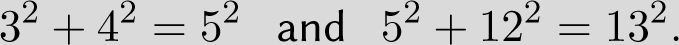

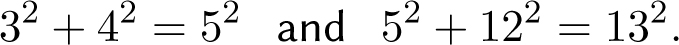

与之相对，当n的数值大于2时，则不存在能满足这个方程的整数a、b和c。这就是费马大定理的主要内容。不过，这一猜想直到1995年才由安德鲁·怀尔斯借助一些来自看起来几乎完全不相关的数学领域、在当时而言十分先进的数学方法最终予以证明。

By contrast, for higher values of *n* it is not possible to find integers *a, b,* and *c* satisfying this equation: this is Fermat’s Last Theorem, but it was not proved until 1995, when Andrew Wiles published a proof using very modern techniques from apparently unrelated fields of mathematics.

### 数字的原则The Principles of Numbers

数字有哪些基本原理呢？对于这些原理，我们往往会因为过于熟悉而难以察觉到它们的存在。以下是一些你也许早已认为是理所当然的关于数字的事实：

What are the basic principles of numbers? We’re so used to them that we don’t even notice them any more. Here are some facts about numbers that you probably take for granted.

• 数字可以相加。

• We can add numbers together.

• 数字可以相减，但结果可能为负。

• We can subtract numbers, but the answer might be negative.

• 数字可以相乘。

• We can multiply numbers.

• 数字可以相除，但结果可能是小数。

• We can divide numbers, but the answer might be a fraction.

• 如果我们给一个数字加上0，则它保持不变。

• If we add zero to a number, it stays the same.

• 如果我们将数字乘以1，则它保持不变。

• If we multiply a number by 1, it stays the same.

• 不能用数字除以0。

• You can’t divide by zero.

• 给一个数字加上另一个数字x，又减掉这个数字x，你会得到原来的数字。

• If you add a number to something and then take it away again, you get back to where you started.

• 让一个数字乘以另一个数字x，又除以这个数字x，你会得到原来的数字。

• If you multiply by a number and then divide by it again, you get back to where you started.

• 几个数字相加的时候，交换它们的位置对结果没有影响。

• When you’re adding numbers, it doesn’t matter what order you do it in.

• 几个数字相乘的时候，交换它们的位置对结果没有影响。但如果你把+、-、×、÷四种运算混合在一起进行计算，则交换数字位置会使结果发生改变。

• When you’re multiplying numbers, it doesn’t matter what order you do it in. But when you’re mixing up +, −, ×, and ÷, it does matter.

• 用0乘以任何数字都会得到0。

• If you multiply anything by 0, you get 0.

• 将任何数乘以 −1，就会得到原来那个数的相反数。（如果它原本就是负数，就会得到“负的负数”。）

• If you multiply anything by −1, you get the negative of what you started with. (If it was already negative, you get “negative negative.”)

• “负负得正。”

• “Negative negative is positive.”

• 把同样的数相加几次就等于把这个数乘以几。

• If you add something to itself several times, it’s the same as multiplying.

类似的“基本原理”还有很多，因此，也许你会想，它们也许能被简化为数量更精简的“超级基本原理”。就像幼女童军的法则一样，只有一条：

This is an awful lot of “basic principles,” so you might wonder if these can be reduced to a smaller number of “extremely basic principles.” Like the fact that there is only one Brownie Guide law:

幼女童军为别人着想，并且每天做一件好事。

*A brownie guide thinks of others before herself and does a good turn every day.*

总的来讲，上面那些我所列出的数学原理越靠后越难。当你刚开始接触数字的时候，你很难理解为什么有加法交换律和乘法交换律，为什么1乘以任何数字并不改变那个数字。（最近的一个研究表明，小学生常常在相关的问题上犯错。）或者，用数字乘以0，为什么会得到0？或者更难的一条，我们是怎么找到“负负得正”这个规律的？

The principles I’ve listed get harder and harder as they go down the list, broadly speaking. When you’re first learning about numbers it’s quite hard to get your head around why order doesn’t matter when you add and when you multiply. What about the fact that multiplying by 1 doesn’t change anything? A recent study of elementary school children showed that they got this wrong an alarming number of times. What about multiplication by zero? *Why* is the answer always zero? Worse, why do we get “minus minus is plus”?

你也许会想，这些原理是从哪里来的？发现事物背后的运行原理叫作公理化（axiomatisation），我们稍后会进一步讨论这个话题。在数学里，这个概念指的是，我们总结出关于某个数学领域的原理，比如关于数字的原理，然后看看这些原理在其他领域是否适用。在后文中你会吃惊地发现，“一个数字乘以0就等于0”并不是一个适用于所有数学领域的基本原理，它是从更基本的原理推导出来的。

You might wonder where those principles came from in the first place. Finding the basic principles behind something is called *axiomatization*, which we’ll come back to later. The idea in math is that we take the basic principles of one world, such as numbers, and see what other worlds obey those principles. You might be surprised to hear that the fact that multiplying by zero gives zero is *not* a basic principle: it’s something we can prove from even more basic principles, as we’ll see later in the book.

它们并不是真的数字，但它们也遵循数字所遵循的那些原理。

They’re not actually numbers, but they obey these same principles.

如果我们去掉乘法交换律这条原理的话，那么还有更多的例子符合数字所遵循的原理。比如矩阵：

If we drop the requirement that the order of multiplication doesn’t matter, we get even more examples. *Matrices* look like this:

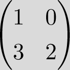

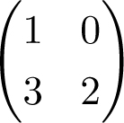

它们遵循关于数字的所有原理，除了乘法交换律。对于这句话的具体含义，我们需要谨慎对待。在我们进一步谈论公理化的内容之后，我们会重新讨论这个问题。

and they obey all the above principles about numbers, apart from the one about the order of multiplication. We do have to be a bit careful exactly what this means, and we’ll see how later on when we do some axiomatization.

这就是理解事物背后的原理的意义——把它们应用到其他领域。

That’s the whole point of understanding the principles—so that you can apply them to places that aren’t quite the same as the ones you first thought of.

### 给好奇者的问题Questions for the Curious

请给下面这个2×2的表格涂色。规则是蓝色和红色在每行和每列都只能出现一次。根据已涂色格子的颜色，你会发现对于剩余的格子，涂色的方法只有一种：

Try coloring in the following 2 × 2 grid. The rule is that each of the two colors has to appear exactly once in each row and exactly once in each column. You should find that there’s only one way of doing it.

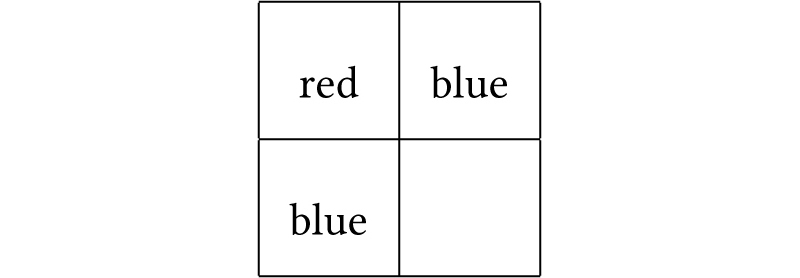

### 给勇敢者的问题Questions for the Bold

请给下面这个3×3的表格涂色，规则与上一个例子相同。

Try this 3 × 3 one, with the same rules.

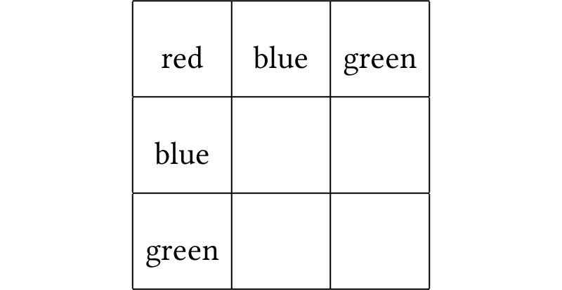

我们会发现，对于剩余的空白格子，涂色的方法仍然只有一种。

There should still be only one way of doing it.

“每样东西在每一行和每一列只能出现一次”这一规则多少有点儿像简化版的数独，这个规则在数学上被称为“拉丁方阵”（Latin square）性质。这是数学中研究“群”概念时的一条十分重要的原理，我们在后文中会再次讨论这个数学分支。

The principle of each thing appearing exactly once in each row and once in each column is a bit like a simpler version of sudoku, and is called the *Latin square* property. It’s a very important principle in math when studying *groups,* a branch of math we’ll come back to later.

### 给无畏者的问题Questions for the Daring

那么，规则不变，下面这个4×4的表格又该如何涂色呢？

What about this 4 × 4 one?

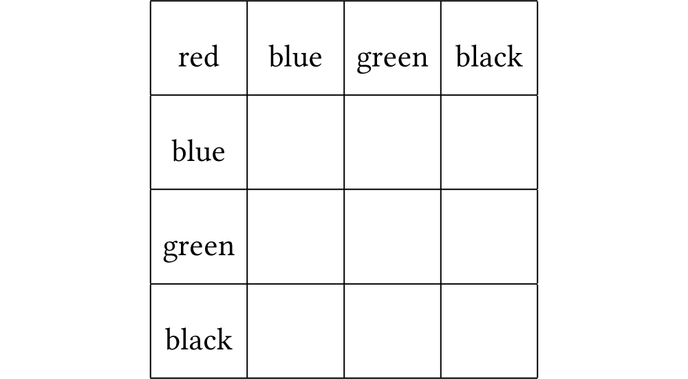

这个表格恰好有4种成立的涂色方案。

There are now exactly four possible ways of doing it.

最后一个问题：如果把颜色换成数字，你会觉得这道题变得更难，还是更简单了？毕竟，颜色本身对问题的解答并没有什么影响。

Last question: would you have found this easier or harder if those had been numbers instead of colors? It didn’t actually matter that they were colors:

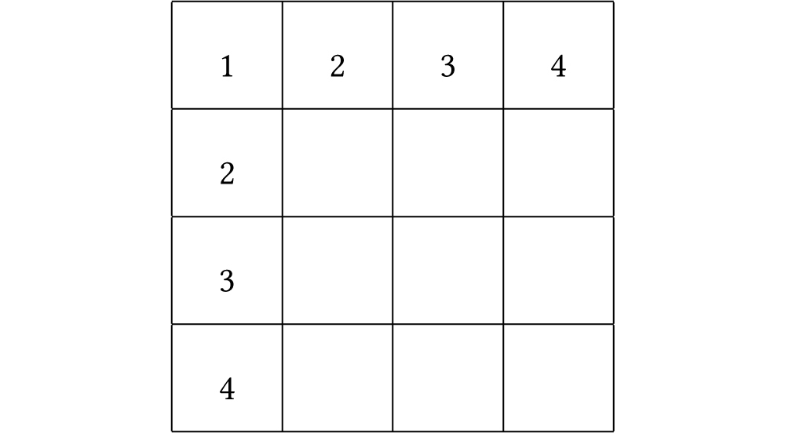

如果换成字母呢？

What about letters?

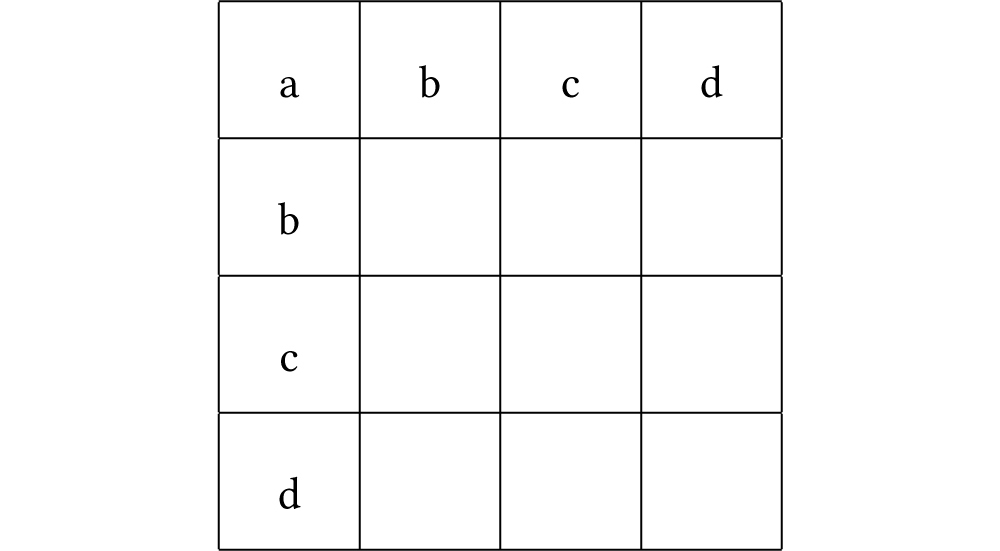

显然，把表格中的某种具体事物替换成数字或字母并不会改变其背后的数学原理，无论出现在表格中的具体事物是什么，这些事物的分布模式都不会改变。

Changing to numbers or letters doesn’t change the mathematics behind the question, which is about the patterns involved, regardless of how the squares are labeled.

给好奇者的问题的解答：只有两种颜色可选，所以直接试一下即可。蓝色不行，因此只能涂红色。

Solution for the Curious: There are only two colors to choose from, so we can just try them. Blue won’t work, so it has to be red.

给勇敢者的问题的解答：从中间的格子开始。它不能是蓝色，否则就会与其他蓝色格子相邻。可以试试红色，但这样它右边的格子就只能是绿色，而那个格子又会与右上角的绿色格子相邻，这是不允许的。因此，中间的格子必须是绿色，它右边的格子必须是红色，整个方格就应当如下所示：

Solution for the Bold: Start with the middle square. It can’t be blue, because then it would be next to the other blue squares. We could try red, but then the square to its right would have to be green, and that would be next to the top right green square, which is not allowed. So the middle square has to be green, and the one to its right has to be red, and the whole square has to look like this:

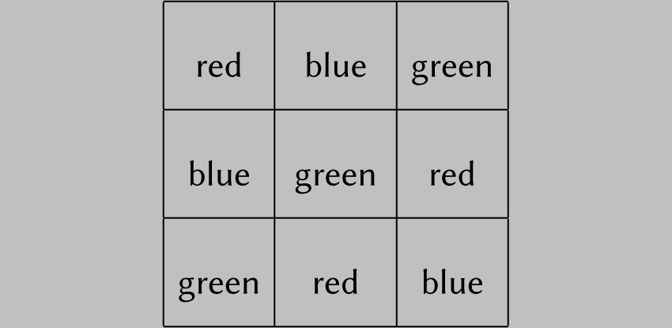

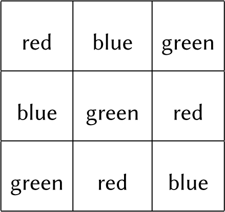

给无畏者的问题的解答：

Solution for the Daring:

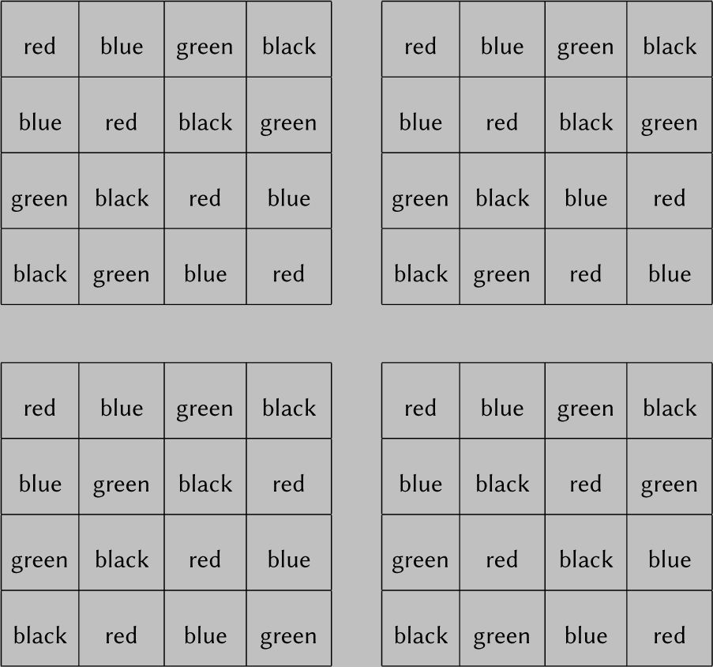

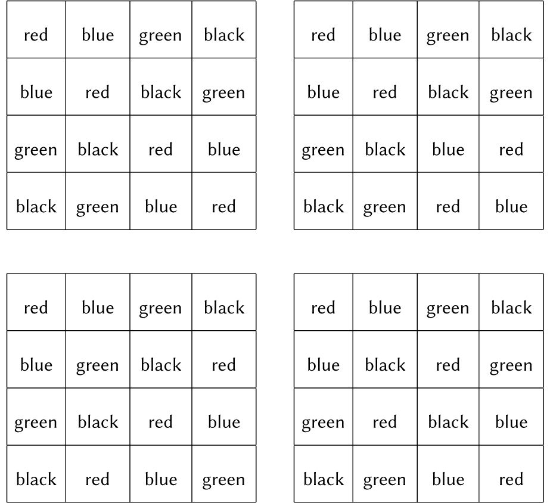

这是一个在称为“有限群分类”的学科中十分深刻的问题。

This is a profound question in a subject called the *classification of finite groups*.

## 4 过程Chapter 4 Process

### 千层酥Puff Pastry

#### 配料Ingredients

1 磅面包粉

1 lb. bread flour

1 磅黄油

1 lb. butter

冷水

Cold water

少许盐

Pinch of salt

#### 做法Method

. . .

将以上这些简单的配料组合起来的方式有很多，但其中的大多数都无法让你做出千层酥。制作千层酥是一个很耗时的过程，很多步骤都对精确性有要求，其中就包括反复的冷却、擀皮和折叠，以制作出千层酥区别于其他面点的美味的奶油“千层”。因为整个制作过程十分复杂，千层酥素来以难做著称。相比之下，它的一个变种，油酥松饼则简单很多。制作油酥松饼需要的配料和千层饼一样（除了黄油使用量更少），而你只需要把配料扔进食物处理机就可以把它做出来了。

There are many different ways of combining these simple ingredients, and most of them will not result in puff pastry. Making puff pastry is a long and precise process, involving repeated steps of chilling, rolling, and folding to create the deliciously delicate and buttery layers that make puff pastry different from other kinds of pastry. Puff pastry has a reputation of being difficult to make because of this process. A basic short pastry is much easier—it uses the same ingredients (but less butter) and you can simply throw them in a food processor.

数学的魅力之一就在于，像做甜点一样，你可以用很简单的配料做出很复杂的成品。当然，复杂烦琐的制作过程也可能会让你感到挫败，就像做千层酥一样。就我个人而言，我倒不觉得做千层酥有那么复杂，只要严格遵循食谱所写步骤去做就可以了。但我相信，即使你不想自己尝试去做，你仍然可以欣赏用如此简单的配料能做出如此美味的甜点这一事实。数学不只是关于结果，它更多地是关于理解得出结果的过程。

One of the wonderful features of math is that, like with pastry, it can use quite simple ingredients to make very complicated situations. This can also make it rather offputting, like making puff pastry. Actually, I don’t think puff pastry is that difficult if you follow the instructions carefully. But even if you don’t want to try doing it yourself, perhaps you can still enjoy the fact that such simple ingredients can turn into delicious puff pastry. Math is about understanding processes and not just eating end results.

### 纽约马拉松比赛The New York City Marathon

#### 并不只是关于从A地到B地Not Just About Getting from A to B

2005年，我参加了纽约市马拉松比赛。我觉得这是一个了不起的成就，所以每每有机会我都会跟人炫耀一番。不过老实讲，说我“跑”了马拉松多少有点儿言过其实——更准确的说法是，我“小跑”着完成了马拉松。但无论如何，我确实从起点出发并最终到达了终点，而且有照片为证。

In 2005 I ran the New York City Marathon. I think this is a great achievement, so I boast about it whenever I can. In all honesty it’s a bit far-fetched to say I “ran” it—it would be more accurate to say I “trotted” it. But I did make it from the beginning to the end, and there are photos to prove it.

纽约市马拉松比赛与其他城市的马拉松比赛有所不同，因为它要求参赛选手从A地跑到B地，比如从史坦顿岛出发，最后跑到中央公园。而其他城市的马拉松比赛，以芝加哥市马拉松比赛为例，选手需要从格兰特公园出发，按照特定路线跑完一圈后最终又回到格兰特公园。然而，没有人会将从A地出发抵达B地视为马拉松比赛的意义——它的真正意义在于你如何到达终点。如果马拉松只是关于到达终点本身的话，那么芝加哥市马拉松比赛的参赛选手只要站在原地不动就可以了。

The New York marathon is different from some other marathons, say, the Chicago Marathon, in that you do actually travel from one place to another place: you start on Staten Island and end up in Central Park. Whereas in Chicago you start in Grant Park and you end up in. . . Grant Park. However, nobody thinks that simply getting from A to B is the whole point of running the marathon—it’s *how* you get to the end. If it were just about getting to the end, then everyone at the Chicago Marathon would just stand still.

告诉别人你跑过马拉松，与告诉别人你是数学家多少有些类似——有些人会觉得你太了不起了，另一些人会觉得你疯了——怎么会有人想去做这件事？

When you tell people you’ve run a marathon it’s actually a bit like telling people you’re a mathematician—some people think you’re amazing and other people think you’re mad. Why on earth does anyone do it?

意义更多地在于过程本身，而不只在于抵达终点。有些旅行的目的就是到达一个目的地（比如早上去单位上班），但其他更多的旅行是关于在途中发现新事物或欣赏美景的。人们很容易将数学理解为一个想办法得出正确答案的过程，而一部分数学分支的确如此。但范畴论更像纽约市马拉松比赛，更多地是关于探索的过程，以及你在这个过程中观察到的事物。它不是关于你具体知道什么，而是关于你究竟是怎么知道的。后者是一个更为微妙的问题。如果我问你“你知不知道某某事”，那么你给出的答案无非是或否。但如果我问你“你是怎么知道这件事的”，那么你的答案就可能很长、很复杂，而且远比你是否知晓这个事实性答案更有趣。

The point is the journey itself, not just the arrival at the destination. Some journeys *are* simply about getting somewhere (for example, going to work in the morning). But other journeys are about a process of discovery or appreciation. It’s easy to think of math as a process of getting the right answer. And some math is like that. But *category theory,* like the New York marathon, is more about the journey and what you see along the way. It’s not about what you know but *how* you know it. This is a much more nuanced question. If I ask you “Do you know such-and-such a fact?” the answer will be either yes or no. But if I ask you “How do you know this fact?” the answer could be very long and complicated, and a lot more interesting than the sheer fact of whether you know it or not.

### 口袋里的钱还在吗？Pickpocket/Putpocket

#### 并不只是关于结果When It’s Not Just About the End Result

假设你口袋里有一张10英镑的钞票。现在，趁你不注意的时候，有人偷了你的钞票。然后，更加奇怪的事情发生了，另一个人偷偷把一张10英镑的钞票放进了你的口袋。对一切完全不知情的你始终相信你口袋里有一张10英镑的钞票，而事实的确如此。但是，你得出此结论的原因完全是错的。那么，你到底是对的还是错的呢？你的结论是对的，但你的推理过程是错的。

Suppose you have a ten-dollar bill in your pocket. Now, without you noticing, someone steals it. Also, and more strangely, someone else slips a different ten-dollar bill *into* your pocket. At this point, you believe you have a ten dollar bill in your pocket. But your reason for believing it is completely wrong. So are you right or not? Your conclusion is correct but your reasoning is wrong.

在数学里，这个答案会被认为是一个错误答案，因为我们感兴趣的是得到正确答案的过程，而不只是答案本身。

This would count as the *wrong answer* in math, because we’re interested in the process of getting to the right answer, not just the answer itself.

以下是一个通过错误推理得到正确答案的例子：

Here’s an example of incorrect reasoning leading to the correct answer.

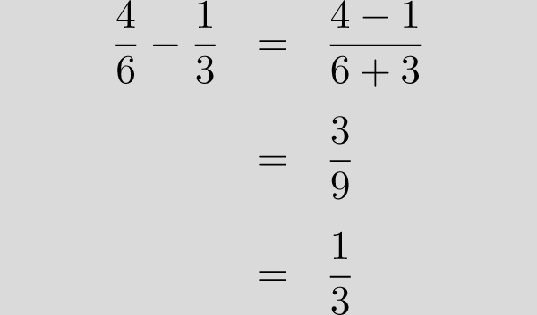

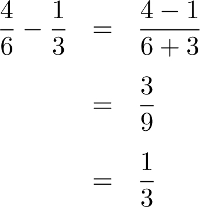

最终答案是对的，但这绝不是正确的分数减法。

The final answer is correct but this is simply not the correct way to subtract fractions.

正确的论证要把各项通分，使分母都变成 6：

The correct argument puts everything over the common denominator 6:

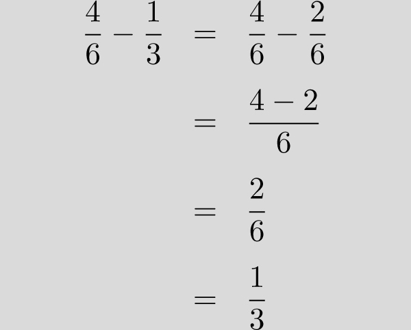

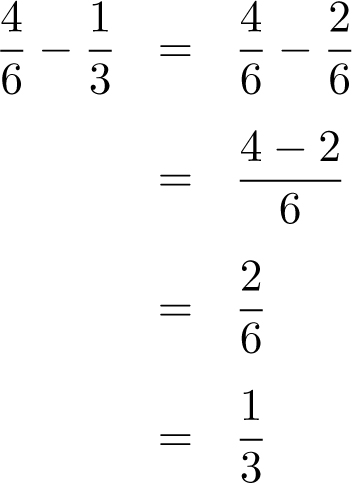

### 欺骗Delusion

#### 手段大于结果When the End Doesn’t Justify the Means

如果有人感到开心，但你觉得他们感到开心的原因是错的，你会干涉他们吗？假如他们是因为一直酗酒而开心，或者是因为相信自己是上帝而开心呢？或者，假如他们是因为他们相信一个你并不相信的上帝在照看他们而开心呢？

If someone is happy, but you think they are happy for the wrong reasons, do you intervene? What if they’re happy because they’re drunk the entire time? What if they’re happy because they’re convinced they’re God? What if they’re happy because they’re convinced that a God you don’t believe in is looking after them?

你会更希望他们转变认知，在认清现实的同时丧失快乐吗？换句话说，只要目的正当、结果正确，就可以不择手段吗？

Would you rather they were correct, but unhappy? Or to put it another way, does the end justify the means?

在数学中，我们永远不能为了结果而不择手段。我们必须选择正确的方法来证明某个命题的正确性，这也是数学方法存在的根本原因。这个过程被称为数学证明，很快我们就会看到它具体是什么样子的。

Math is a world in which the end does *not* justify the means: quite the reverse. The means justifies the end; that’s the whole reason it’s there. It’s called *mathematical proof,* and we’ll see what that looks like shortly.

### 积非成是Two Wrongs Make a Right

#### 为什么数学并不只是关于得到正确答案Why It’s Not All About Getting the Right Answer

在我给我的学生们出的数学测试题里，我会标明哪些是他们必须将运算分解成很多小步骤写出来的题目。而我往往会发现，在某些步骤中，他们很容易把正号和负号搞混，从而因为多除了一个-1而把最终答案写错。如果正确答案是100，他们很可能会得到-100的错误答案。

I have marked exam questions where students were asked to do some sort of calculation in many small steps. As it turned out, there were several steps where they were prone to making a plus/minus error, which could result in them getting the answer wrong by a factor of −1. So if the answer was supposed to be 100, they would get the answer −100 by mistake.

问题是，如果他们犯了两个这样的错误，答案就碰巧被修正了，最后他们会得到正确答案100。我记得在某次测试的一道运算题中，大概在其中的6个步骤中，这样的错误都是很容易发生的。所以，只要他们犯错的次数是偶数次，他们就会得出正确的答案，但事实上，在这个正确答案的背后，很可能是其推理过程中的2个、4个或6个错误。

The trouble was, if they made *two* of these errors, the error would correct itself and they’d go back to getting 100. I seem to remember there were about six steps with the potential for making this mistake. So as long as they made the mistake an even number of times, they would still get the right answer. But they would have two, four, or six mistakes in their reasoning.

在数学科学中，除了算数和其他你在中学能学到的数学知识以外，对于其他所有的数学分支来说，你能肯定你的答案是正确的唯一方法就是确保你的推理过程是正确的。这可不像寻找埃菲尔铁塔，当你看到埃菲尔铁塔出现的时候，你就知道你找到它了，因为每个人都知道埃菲尔铁塔的样子。这更像是古代探险家的探索活动，他们没有全球卫星定位系统，也没有地图，所以他们知道自己在哪里的唯一办法就是非常小心谨慎地规划路线。

In math beyond the level of arithmetic and other high school math, the only reason you know you have the right answer is by checking that your process was correct. It’s not like when you’re trying to find the Eiffel Tower and you know when you’ve found it because everyone knows what the Eiffel Tower looks like. It’s more like explorers in times gone by, who had no GPS and no maps, so the only way they could know where they were was by plotting their route very carefully.

### 为什么？为什么？为什么？Why? Why? Why?

#### 为什么孩子们有他们的理由Why Small Children Have a Point

如果你有跟三岁孩子相处的经验的话，你就会知道他们会不停地问为什么，从不停下。

If you’ve ever spent time with a three-year-old, you’ll know that children that age never stop asking why. Ever.

“我为什么不能吃更多的甜点？”

“Why can’t I have more dessert?”

因为你已经吃得够多了。

Because you’ve had enough.

“为什么？”

“Why?”

因为不然的话，你就会摄入过多的糖，然后你就会睡不着。

Because otherwise you’ll have too much sugar and won’t go to sleep.

“为什么？”

“Why?”

呃，因为你的血糖水平会急剧上升，你的代谢率也会突然上升，然后……

Um, because your blood sugar levels will spike and your metabolic rate will suddenly go up and. . .

不幸的是，我们往往会选择压抑孩子问为什么的天性，仅仅因为被问了几次以后我们就会感到厌烦，因为我们很快就到了回答不出来的时候。并且，我们不喜欢被迫承认“我不知道”，因为大多数时候我们都不喜欢被挑战理解能力和知识储备的极限。

Unfortunately, we suppress this instinct in children, possibly just because it gets rather tiresome after a while. Possibly because we quite quickly get to the point where we don’t know the answer, and we don’t like having to say “I don’t know.” Or we don’t like reaching the end of our own understanding of things.

但孩子们的这种本能仍然很美好，这是知道与理解之间的差别。有些时候，孩子们只是想缠着大人，或者推迟睡觉时间，但我认为大多数时候，他们是真的被某些问题困扰着，想要更好地理解它们。

But this natural instinct in children is beautiful. It’s the difference between *knowledge* and *understanding*. Sometimes they’re just trying to pester the adults or put off going to bed, but often I think they really are baffled by things and are trying to understand them better.

数学的核心就是理解事物，而不仅仅是知道它们。在某种意义上，我从未停止过像一个学步期的孩子一样问“为什么”。数学是我认为可以用来探索那些问题的答案的最让人满意的方法。因此，不可避免地，我开始对数学本身提出“为什么”，而这就是范畴论开始的地方。

At the heart of math is the desire to understand things rather than just know them. In some ways I just never stopped being that toddler who keeps asking “Why?” Math is the most satisfying way I found of answering those “Why?” questions. But then, inevitably, I started asking “Why?” about math itself, and that’s where category theory comes in.

### 数学证明Mathematical Proof

在数学里，我们用“证明”的方式来解答关于“为什么”的问题。数学里的证明比我们在日常生活中用到的证明更为有力。正如我们在第二章提到的，这种证明并非关于搜集证据，而是关于运用逻辑。

In mathematics the question “Why?” is answered in the form of a *proof*. Proof in math means something a bit stronger than in normal life. As we discussed in the chapter *Abstraction*, it’s not about gathering evidence but about using logic.

例如，你也许想要证明所有的乌鸦都是黑色的。于是你开始找乌鸦。你看到的第一只是黑的，第二只也是黑的，第三只还是黑的。你继续找下去。那么，什么时候你才能肯定你已经找到足够的证据说明所有的乌鸦都是黑色的呢？在你找到一百只以后？一千只以后？一百万只以后？即便你真的做到了，这个世界上还是可能有一只古怪的紫色乌鸦存在。

For example, you might try to prove that all crows are black. You start looking for crows. The first one you see is black. The second one you see is black. The third one you see is black. You keep going. When do you decide you have enough evidence that all crows are black? After a hundred? A thousand? A million? There could still be one freak crow out there that is purple.

问题在于，乌鸦的特征并不遵循逻辑，因而试图用逻辑证明它们只有某种颜色很难。比如，你可能必须找到一些不可辩驳的基因证据才能说明乌鸦只能是黑色的。

The thing is, crows don’t really behave according to *logic,* so a logical proof would be quite difficult. You’d have to do something like find some irrefutable genetic cause of crows being black.

这就是为什么在数学里我们只关注那些遵循逻辑的事物。事实性的证据为我们提供了一个开端，让我们可以坐下来尝试着运用数学方法进行论证——但这个基于实证的假设仍然可能是错的。事实上，在很多时候，你会发现某个有充足“证据”的假设，并认为它很可能是正确的，于是你决定坐下来试着用数学方法来论证它的正确性，结果却发现它完全是错误的。

This is why, in mathematics, we focus entirely on things that *do* behave according to logic. The evidence gives us a hint of something we might sit down and try to prove using mathematical methods—but it could still be wrong. It happens plenty of times in research math that you sit down to try and prove something that you think might be true because of some “evidence,” and the whole thing turns out to be completely false.

举个例子，如果我们想要证明下面这个假设：

What if we try and prove this:

所有的正方形都有四条边。

*All squares have four sides.*

这个例子看起来有点儿蠢，毕竟正方形的定义就规定了它有四条边。（乌鸦的定义有没有规定它必须是黑色的？）但如果我们要证明这个命题，我们就不能仅仅是因为“定义如此”就简单认定它是正确的。

This is a bit silly—it’s inherent in the definition of a square that it has four sides. (Is it inherent in the definition of a crow that it is black?) We need to try and prove something that isn’t simply true by definition.

或者，让我们试试证明下面这个假设：

Let’s try and prove this:

所有能被6整除的数字都能被2整除。

*Any number divisible by 6 is also divisible by 2.*

我们可以先试着找一些证据。哪些数字能被6整除呢？12肯定可以，并且它也能被2整除。18呢？是的，也能被6和2整除。24呢？也可以。此时，你就可能产生一种这个假设应该没错的感觉。这种感觉是很重要的，在此基础之上，你才会希望证实这种感觉是对的，从而最终真正确信假设的正确性，而说服人们确信某事正是数学的使命。

We could start by looking for some evidence. Which numbers are divisible by 6? Well 12 is definitely divisible by 6, and yes, it’s also divisible by 2. What about 18? Yes, that works. What about 24? Yes, that works. At this point you might *feel* very convinced. And that is important—feeling convinced is an important part of *being* convinced, and convincing people of things is the whole point of math.

你能证明为什么以上这个假设是真的吗？你也许会意识到这与6是一个偶数有关。

Can you instead work out *why* this is true? You might realize that it’s something to do with 6 being an even number.

但这里我们不需要把24进行质因数分解——只要分解出一个2，我们就知道24可以被2整除了。

but we don’t need to here—once one 2 has appeared in the product we know that 24 is divisible by 2 and we can stop.

这是不是意味着所有能被6整除的数字都必须是偶数呢？事实上的确如此。现在我们来看一下为什么。首先，我们应该用以下这种表达来更精确地陈述这个事实。我们用字母A来替代“所有数字”。

Does this mean that any number that’s divisible by 6 must also be an even number? It does, and now we’ll investigate why. First we should make that fact more precise by using the following statement, in which we’ll write *A* to stand for “any number.”

如果A能够被6整除，并且6能够被2整除，那么A就能够被2整除。

*If A is divisible by 6, and 6 is divisible by 2, then A is divisible by 2.*

我们现在可以将这个结论进行推广，用任意数字B替代6，用任意数字C替代2。由此，我们就得出以下事实：

We can now make this work more generally: instead of 6 we could have any number *B*, and instead of 2 we could have any number *C*. Then we get the following fact:

如果A能够被B整除，并且B能够被C整除，那么A就能够被C整除。

*If A is divisible by B, and B is divisible by C, then A is divisible by C.*

对于用字母来替代所有数字这种做法，你感觉如何？这个步骤是很多人对数学感到不习惯的开始。对有些人来说，这个抽象化的步骤太复杂了，但它带来的好处很明显：我们现在对数字的规则有了更广泛的理解，而不只是知道一个特定的关于数字6和2的事实了。因为A、B和C可以是任意数字。

How do you feel about replacing all those numbers by letters? That is one moment when many people start feeling uncomfortable about math. It’s a step of abstraction too far for some people, but it has a point: because *A*, *B*, and *C* can be *any numbers*, we can now understand something more broadly true about numbers, not just about the particular numbers 6 and 2.

并且，这一抽象化步骤能让我们从一个更宏观的视角来看待这个问题，从而找到与这个结论类似的其他情形。你能看出以上含有A、B和C的结论与下面几个结论的共通之处吗？

Moreover, this process of taking a step back allows us to draw analogies with other things we might have seen. Can you see how the statement above, with *A*, *B*, and *C*, is analogous to these ones?

• 如果 A比B大，并且B比C大，那么A就比C大。

• If *A* is bigger than *B*, and *B* is bigger than *C*, then *A* is bigger than *C*.

• 如果A比B便宜，并且B比C便宜，那么A就比C便宜。

• If *A* is cheaper than *B*, and *B* is cheaper than *C*, then *A* is cheaper than *C*.

• 如果A等于B，并且B等于C，那么A就等于C。

• If *A* is equal to *B*, and *B* is equal to *C*, then *A* is equal to *C*.

此类关于A、B、C的关系被称为“传递性”（transitivity）。数学家们给了这类关系一个名字，因为它们在许多情形下都会出现，而通过命名，我们便可以迅速指认它们，并提醒自己注意其他类似的情形。以下是一些你可以试着应用这种传递性的其他关系。

This sort of relationship between *A*’s, *B*’s, and *C*’s is called *transitivity.* Mathematicians have given it a name because it crops up in many different situations, so it’s useful to be able to refer to it quickly and remind yourself of other similar situations. Here are some other relationships you can try this on.

假设A、B和C都指人。

Suppose *A*, *B*, and *C* are people.

1.如果A比B年龄大，并且B比C年龄大，那么A是否比C年龄大？

1. If *A* is older than *B*, and *B* is older than *C*, does that mean *A* is older than *C*?

2.如果A比B高，并且B比C高，那么A是否比C高？

2. If *A* is taller than *B*, and *B* is taller than *C*, does that mean *A* is taller than *C*?

3.如果A是B的妈妈，并且B是C的妈妈，那么A是否是C的妈妈？

3. If *A* is the mother of *B*, and *B* is the mother of *C*, does that mean *A* is the mother of *C*?

4.如果A和B是姐妹，并且B和C是姐妹，那么A是否是C的姐妹？

4. If *A* has the same birthday as *B*, and *B* has the same birthday as *C*, does that mean *A* has the same birthday as *C*?

5.如果A和B是朋友，并且B和C是朋友，那么A是否是C的朋友？

5. If *A* is a friend of *B*, and *B* is a friend of *C*, does that mean *A* is a friend of *C*?

6.如果A和B是夫妻，并且B和C是夫妻，那么A和C是否为夫妻？

6. If *A* is married to *B*, and *B* is married to *C*, does that mean *A* is married to *C*?

7.假设A、B和C均指地点。如果A在B的东面，并且B在C的东面，那么A是否在C的东面？

7. Now suppose *A*, *B*, and *C* are places. If *A* is east of *B*, and *B* is east of *C*, does that mean *A* is east of *C*?

问题1和问题2的答案必然是肯定的。但问题3不是——如果A是B的妈妈，并且B是C的妈妈，那么A就是C的外婆。因此我们得出结论，即某人是另一人的母亲这件事并不具有传递性。不过，某人是另一人的姐妹这件事是有传递性的。那么某人是另一人的朋友这件事呢？你是你朋友的所有朋友的朋友吗？

The first two are definitely true. But the third one isn’t—if *A* is the mother of *B*, and *B* is the mother of *C*, then *A* is the *grandmother* of *C*. So we say that being someone’s mother is not transitive. Having the same birthday as someone is transitive, however. What about being someone’s friend? Are you friends with all the friends of your friends?

那么和某人结婚这件事呢？如果我们生活在多配偶制被法律禁止的社会中的话，你就只能跟一个人结婚。也就是说如果A和B是夫妻，并且B和C是夫妻，那么A和C就必须是同一个人。也就是说，A和C肯定不是夫妻。

What about being married to someone? If polygamy isn’t allowed, then you can only be married to one person. That means if *A* is married to *B*, and *B* is married to *C*, then *A* and *C* must be the *same person*. And that definitely means *A* is not married to *C*.

最后我们来看看第7个问题。如果A、B和C这三个地点都在同一个城市或国家的话，这个问题的答案就是肯定的。但如果这三个地点是地球上的任意地点的话，问题答案是否肯定就不确定了，因为地球是圆的，你可以往东一直走下去，最终回到原点。在这个例子里，比起允许三个地点是世界上的任意地点，设定一些限制（比如三个地点在同一个城市或国家）能让这个问题变得更容易理解。

Finally let’s think about (7). If the three places *A*, *B*, and *C* are all within one city or one country, then this is true. But if we encompass the entire world, then we get into trouble because we can go round in circles. You can keep going east for a long time and end up back where you started. This is a case where restricting your scope (to a single city or a single country) makes things easier to understand than looking at the entire world.†

现在让我们回到数字的例子。“可以被某个数整除”具有传递性。但为了有效地证明这个结论，我们需要把“可以被某个数整除”变成一个可以用逻辑规则来检验的精确描述。这又是另一个可能让人们感到不习惯的步骤。为了能够运用逻辑规则，我们必须离开我们已经熟知的那些关于数字的知识和情境，离开我们的舒适区。但这一做法的长远回报是巨大的——有很多领域是你可以借助逻辑推理来理解却无法用本能和直觉来理解的。就像你必须离开舒适的家才能登上飞机去看世界一样。

Now let’s go back to our example with the numbers. “Being divisible by something” *is* transitive. But in order to prove that properly, using rigorous logic, you have to turn “being divisible by something” into a precise statement that can be manipulated using logic. This is another step that can make people feel uncomfortable. In order to get into a position to use logic, we have to leave the place where we use what we feel we understand about numbers—we have to leave our previous comfort zone. But the long-term gains are large, because there are places you can go with logic that you can’t go with your gut feeling and instinct. It’s like the fact that you have to leave the comfort of your home in order to get on a plane and see the world.

具体而言，在我们这个整除的例子里，这个步骤是这样做的：

Here’s what that step looks like for our divisibility example.

A可以被B整除，

*A is divisible by B*

意味着，

means

A是B的整数倍，

*A is a multiple of B*

也就是说，

which means

A＝k×B，其中k是整数。

*A* = *k* × *B for some natural (whole) number k.*

现在我们可以开始论证了。当我们用精确的数学语言来描述这个问题时，我们会使用一种非常特殊的描述结构，从而让每个人都能理解并同意你所描述的东西。这就像是在写一个有开头、中间情节和结尾的故事，只不过在告诉每个人中间情节是什么之前，你先告诉了他们结尾是什么。

Now we’re ready to go on our journey. When we do this in precise mathematical language we use a very specific structure so that everyone can agree on what just happened. It’s like writing a story with a beginning, a middle, and an end, except that you tell everyone what the end is going to be, before telling them what the middle is.

开头就是你对于假设和定义的描述。就像设定故事的主要场景，或者在戏剧的开场列出全体演员的名单一样。它很可能看起来就像这样：

The beginning is where you state what your assumptions and definitions are. It’s like setting the scene in a story, or writing out a cast list at the beginning of a play. It might look like this.

**定义** 对于任意自然数A和B，只要A＝k×B，并且k是自然数，我们就说A可以被B整除。

**Definition.** *For any natural numbers A and B, we say A is divisible by B* *whenever A* = *k* × *B for some natural number k.*

现在我们告诉所有人这个故事的结尾是什么，也就是我们的目标结论。在数学里，对不同结论的命名有高下之分，这取决于结论的重要性和开拓性。一个重要性较小的结论被称为“辅助定理”或“引理”（lemma），一个中等重要的结论被称为“命题”（proposition），一个相当重要的结论被称为“定理”（theorem）。当人们觉得一个结论可能为真，但该结论还未被证明，那么这一结论就被称为“猜想”（conjecture）或“假说”（hypothesis）。因此，我们有“庞加莱猜想”和“黎曼猜想”，也有“费马大定理”。

Now we tell everyone what the end is, that is, the end result that we’re going to aim for. In math there’s a hierarchy of names for end results depending on how magnificent and groundbreaking they are supposed to be. A small one is called a *lemma,* a medium-sized one is a *proposition*, and a properly important one is called a *theorem.* When something is suspected to be true but hasn’t actually been proved yet, it’s called a *conjecture* or a *hypothesis*. Hence there was the “Poincaré Conjecture” and the “Riemann Hypothesis” but there’s also “Fermat’s Last Theorem.”

事实上，数学家们在给这些结论命名时并非总是意见一致：一个结论该被叫作“猜想”还是“假说”并没有非常确切的标准。不仅如此，以费马大“定理”为例，费马大定理一直被称作“定理”实际上并不合规，因为它是在这样被命名了358年后才有人发表了对它的第一个证明。在此之前，它只是一个未被验证的猜想或者假说。此外，还有一些非常重要的结论却被称作“引理”，这听起来像是假谦虚，实际上则很可能是因为在最开始完成论证时，它们的重要性还未被充分认识到。

In fact the process of naming things is not very consistent: it’s not clear why one thing should be called a conjecture and another a hypothesis. Moreover, Fermat’s Last “Theorem,” which we described in the chapter *Principles* was called a theorem for 358 years before a proof was ever published, which isn’t really fair. Some extremely important things are called “Lemma,” which sounds a bit like false modesty, but could also be because their importance was not recognized at first.

庞加莱猜想讨论的是哪些三维形状是可能存在的。它是对于以下二维定论的三维版推论：如果一个二维的曲面没有棱角，并且这个二维曲面是一个没有洞的三维实体的曲面，那么这个二维曲面一定是球面。我们很难想象这个结论的高维推论，因为这要求我们想象出四维的实体——一个难以视觉化，却很容易借助数学推导出来的概念。昂利·庞加莱在1904年提出这个猜想，它被称作“猜想”是因为庞加莱不知道怎么证明它。直到100年后，这个猜想才最终被格里戈里·佩雷尔曼证实。

The Poincaré Conjecture is about what sorts of 3-dimensional shapes are possible. It is a 3-dimensional generalization of the following fact: if a 2-dimensional surface has no edges, and is the surface of a 3-dimensional solid with no holes, then it must be a sphere. It is hard to imagine what this could mean in the higher-dimensional version because it requires us to imagine 4-dimensional solids. This is something that is difficult to visualize but easy to reason with in mathematics. Henri Poincaré proposed this in 1904, and it was called a conjecture, as Poincaré did not know how to prove it. It was finally proved by Grigori Perelman a hundred years later.

黎曼猜想是关于质数分布的。质数就是只能被1和它本身整除的数，最初的几个质数是2、3、5、7、11、13、17……你也许觉得它们应该有某种规律，但其实不然：我们无法预测质数会在哪里出现。但我们有办法预测它们更可能出现在哪些地方，黎曼猜想就是一个很好的预测方法。波恩哈德·黎曼于1859年提出了这个猜想，但该猜想直到今天仍未被最终证明，所以到目前为止，它仍然被称作“猜想”。

The Riemann Hypothesis is about the distribution of prime numbers. A prime number is one that is only divisible by 1 and itself, and the first few are 2, 3, 5, 7, 11, 13, 17, . . . . You might think they form some sort of pattern, but they do not: there is no way of knowing where prime numbers are going to pop up. However, there are ways of predicting where they are more likely to appear, and the Riemann Hypothesis gives a particularly good way of doing this. This was proposed by Bernhard Riemann in 1859 and to date has still not been proved, so it is still called a hypothesis.

我们想要证明的关于整除性的结论是关于数字的一个比较重要的结论，所以，依据前文的定义，我把它称作一个命题。

The thing we’re proving here about divisibility is fairly important in the context of numbers, so I’m going to call it a proposition.

**命题** 如果A可以被B整除，并且B可以被C整除，那么A就可以被C整除。

**Proposition.** *If A is divisible by B and B is divisible by C, then A is divisible by C.*

我已经告诉了你故事的开头和结尾，现在，我要告诉你这个故事最重要的部分了：中间情节，也就是从开头走向结尾的整个过程。这就是数学证明。

Now that I’ve told you the beginning and the end of the story, I’m going to tell you the important part: the middle, the process of getting from the beginning to the end. This is called the proof.

**证明：**  
假设：

**Proof.** Suppose

1. A可以被B整除，即A=k×B，其中k为自然数，并且

1. *A* is divisible by *B*, so *A* = *k* × *B* for some natural number *k*, and

2. B可以被C整除，即B=j×C，其中j为自然数。

2. *B* is divisible by *C*, so *B* = *j* × *C* for some natural number *j*.

则A=k×j×C，并且k×J是自然数。

Then *A* = *k* × *j* × *C*, and *k* × *j* is a natural number.

所以A=m×C，其中m为自然数。

Therefore *A* = *m* × *C* for some natural number *m*.

因此，根据定义，A可以被C整除。

So by definition, *A* is divisible by *C*.

**证明****完毕。**

**The end.**

数学家并不会真的在证明的结尾写上“证明完毕”这几个字，他们通常会画一个正方形表示证明完毕，或者写下“QED”这三个字母，即“quod erat demonstrandum”的缩写，该短语可大致翻译为“这就是我们试图证明的结论”。

Mathematicians don’t really write “The end” at the end; instead they will just draw that box over on the right to signify the end, or they will write “QED.” This stands for “Quod erat demonstrandum,” which roughly translates as “which is the thing that we were supposed to demonstrate.”

你有没有跟上我们刚刚的证明步骤？你是否在我们探讨证明过程之前就对原先的结论感到很满意了呢？下面有另外一些关于“为什么”的问题及其对应的不同强度的答案。你可以问问自己，对于这些答案，你是会认为它们不够有说服力，还是对其感到满意，抑或认为这种解释过于复杂，没什么必要呢？根据你的答案，你可以判断出你更适应哪种程度的抽象。

Did you get lost somewhere in that proof? Were you perfectly happy with the original answer before we went into the mathematical details? Here are some other “why” questions with various levels of answer. You can ask yourself whether you find each answer inadequate, satisfying, or over the top, to see what sort of level of abstraction you like.

问题：为什么有人会用三脚凳？

**Question:** *Why does anyone use a three-legged stool?*

1. 因为三脚凳比四脚凳更为牢靠。

a) Because a three-legged stool is more stable than a four-legged stool.

2. 因为当你把四脚凳放在地上时，其中一只脚可能会因为比另外三只脚高出一些而无法完全与地板贴合，这样一来这个凳子坐起来就会没有那么稳固。

b) Because if you try and put four legs down on the floor, one of them might stick up a bit more than the others, leaving a gap between it and the floor, which means the stool could wobble.

3. 因为经过三维空间中的任意三点的平面有且只有一个，而经过三维空间中任意四点的平面可能并不存在。

c) Because given any three points in 3-dimensional space, there is a plane that goes through them all. Whereas given any four points, there might not be a plane that goes through them all.

问题：为什么八度音听起来很悦耳，而其他的音符组合听起来没有那么和谐？

**Question:** *Why does an octave sound nice whereas other combinations of notes sound discordant?*

1. 因为八度音本质上是同一个音的两个版本，所以它们组合在一起听起来很和谐。

a) Because an octave basically consists of two versions of the same note, so they fit nicely with each other.

2. 因为八度音是一种天然泛音，所以当你弹其中一个音的时候，比它高八度的和声就已经产生了。

b) Because an octave is a natural harmonic, so when you play one note the harmonic of the octave above is already sounding anyway.

3. 因为高八度音的波长是低八度音的波长的一半，所以它们彼此不会干扰。

c) Because the wavelength of an octave above is exactly half the wavelength of the octave below, so there’s no interference between them.

在以上每个例子里，所有三个答案都是正确的，但它们分别提供了不同强度的解释。现在，请你问问你自己，你是对第一个答案感到满意？还是仍然好奇，想要寻求更深层次的解答？你的选择完全属于个人偏好，其关乎你愿意将哪种事实认同为“基本”事实或“既定”事实。除了逻辑规则，数学几乎不假定任何事实是基本的或者既定的——它总是在寻求更深层次的解释。

In each case all three answers are correct, but offer different levels of explanation. It is a matter of personal taste whether you are satisfied with the first answer or are still curious and seeking further explanation. It’s about what sorts of facts you’re happy to accept as “basic” or “given.” Math tries to take almost nothing as basic or given, apart from the rules of logic. It always seeks further explanation.

也许听起来不像，但这个问题其实是一个真实存在的数学问题。数学家会通过先将目光聚焦于小的区域来研究复杂的大区域问题。他们甚至会在数学分析中用到“社区”这个词。

† It might not sound like it, but that was actually a genuine mathematical example. Mathematicians study large and complicated surfaces by first restricting their scope to small neighborhoods. They even use the word “neighborhood.”